Skip to contents

# 📉 CMSY++仅渔获量资源评估

Source: [`vignettes/articles/zh/cmsy.Rmd`](https://github.com/Linbojun99/faofishingreport/blob/main/vignettes/articles/zh/cmsy.Rmd)

```r
fao_settings(lang = "zh")   # 本文所有图表使用中文
```

CMSY++（Froese et al. 2023）是CMSY（Froese et al. 2017）的后续版本，它根据渔获量序列、内禀增长率r的先验和相对生物量B/k的先验，估计MSY、Bmsy、Fmsy，以及每年的相对生物量B/Bmsy和相对捕捞强度F/Fmsy。本包内置了CMSY++的官方代码（`CMSY++16.R`，2021年1月版）、神经网络文件和用户手册（Froese et al. 2021），由几个函数完成从安装JAGS（Plummer 2003）到出图的全部步骤。本文展示的CMSY++结果是事先运行得到的，生成本文时不会运行CMSY++。

**FishStat只有渔获量，没有CPUE。**FAO捕捞产量数据不含CPUE、调查生物量等丰度指数，所以每个种群都只能走CMSY++的仅渔获量路线（CMSY，`btype = "None"`），不会运行贝叶斯Schaefer模型（BSM）。这时结果主要取决于B/k先验。独立检验发现，在默认先验下，仅渔获量方法对种群状态的判断精度有限（Free et al. 2020；Ovando et al. 2021；Kell et al. 2022）。因此结果只是**指示性的**，不能替代正式的种群评估。按照FAO（2026）的做法，状态只分两类：**最大可持续捕捞**（最后一年B/Bmsy ≥ 0.8）和**过度捕捞**（B/Bmsy < 0.8），不使用仅渔获量结果判定“低度捕捞”。

**CMSY++免责说明与来源。**CMSY++由Rainer Froese等人开发（Froese et al. 2021, 2023）。本包与CMSY++的作者无关联，也未得到其认可。本包内置的是作者发布的2021年3月版原始文件（GEOMAR OceanRep，记录[52147](https://oceanrep.geomar.de/id/eprint/52147/)，CC BY 4.0），同样的代码也发布在GitHub：https://github.com/SISTA16/cmsyPlusPlus。`cmsy_run()`运行的是它的一份副本，所做的修改都列在每个运行文件夹的`code_changes.csv`中（操作系统设置、不自动安装R包），不改变方法本身。方法上的问题请咨询CMSY++的作者；本包运行CMSY++时出现的问题请提交到[faofishingreport的Issues](https://github.com/Linbojun99/faofishingreport/issues)。评估结果需由使用者自行核对和解释。

## ⚙️ 通用参数

下面这些参数在所有带有它们的CMSY函数中含义相同；后面各函数的参数表只列出其他参数。

| 参数 | 含义 | 默认值 |
| --- | --- | --- |
| `stocks` | 要使用的种群：种群代码（如`"PRA_27"`），或物种的英文名、中文名、学名或FAO三字母代码（该物种的所有种群） | `NULL`：全部种群 |
| `table` | 是否保存表格（在`tables/cmsy/`） | `TRUE` |
| `lang` | 图中文字、名称和表格列名的语言：`"en"`、`"zh"`或`"both"` | `NULL`：使用`fao_settings()`设定的语言（未修改时为`"en"`） |
| `pptx` | 是否同时把图保存为可编辑的PowerPoint文件（在`figures/pptx/cmsy/`） | `FALSE`；`fao_settings(pptx = TRUE)`可对所有函数生效 |
| `plot_show` | 保存图表的同时把图画在绘图窗口中（例如RStudio的Plots窗格） | `FALSE`，或`fao_settings()`中的`plot_show` |
| `annotations` | 在坐标轴标题和刻度之外加入的文字：`FALSE`不加，`TRUE`全部加入，或`"title"`、`"subtitle"`、`"caption"`、`"legend"`和`"labels"`（图内文字）中的任意几项 | `FALSE`；`options(faofishingreport.cmsy_annotations = TRUE)`可改变本次会话的默认值 |
| `silent` | 是否不显示进度条和提示信息 | `FALSE`；`fao_settings(silent = TRUE)`可改变本次会话的默认值 |
| `data_dir` | 存放下载文件的文件夹 | `fao_data_dir()` |

## 🚀 一步完成：cmsy_area()

```r
cmsy_setup()                                                     # 第一次使用前：安装JAGS和R包
area27 <- cmsy_area("Atlantic, Northeast", top = 10)
```

`cmsy_area()`把下文第四步到第七步以及第九步合成一步：选出某个渔区近`recent_years`年渔获量最大的`top`个物种（也可以用`species`直接指定），依次准备输入、运行CMSY++、画全部图表、做情景预测、写表格，每一步都有进度条。无法评估的主要物种（如没有r先验）会列出原因。`area`可以是多个渔区，每个渔区的结果保存在`out_dir`下各自的文件夹中，并分类存放：

```
cmsy_areas/Atlantic__Eastern_Central/
├── input/      CMSY++渔获文件和ID文件（catch.csv、id.csv）、所评估的种群（stocks.csv），
│               以及未能评估的主要物种及原因（excluded.csv）
├── runs/       每个种群的CMSY++原始输出（JPEG图、cmsy_output.csv、log.txt）、修改后的代码
│               和修改清单（code_changes.csv）
├── figures/    每个种群一个文件夹，另有summary/汇总图（pptx = TRUE时还有figures_pptx/）
└── tables/     results.csv、series.csv、priors_table.csv、results_table.csv、forecast.csv、
                forecast_share.csv、settings_used.csv和sources.csv
```

| 参数 | 含义 | 默认值 |
| --- | --- | --- |
| `area` | FAO主要渔区名称（可以是多个），写法与`fishing_area_data()`相同（如`"Atlantic, Eastern Central"`），也可以是`fishing_area_data()$area_data`这样的FAO产量数据 | 必填 |
| `top` | 评估渔获量最大的几个物种 | `10` |
| `species` | 改为评估指定的物种：英文名、中文名、学名或FAO三字母代码 | `NULL` |
| `recent_years` | 按数据最后`recent_years`年的平均渔获量给物种排序 | `10` |
| `out_dir` | 在其中为每个渔区建一个文件夹 | `"cmsy_areas"` |
| `auto_start` | 起始生物量难以判断时，是否从CMSY++建议的年份开始（见第五步） | `TRUE`（`cmsy_run()`中为`FALSE`） |
| `seed` | 随机数种子，使结果可以重复 | `1` |
| `parallel` | 同时运行的种群数；每个种群的两条MCMC链还会另外占用两个进程 | `NULL`：处理器核数的一半 |
| `settings` | 替换CMSY++默认值的设置（见CMSY++自带的设置） | `list()`：不修改 |
| `charts` | 要画的图（见第六步） | 全部 |
| `classes` | 状态分级：`"fao"`（两级）或`"palomares"`（五级） | `"fao"` |
| `forecast` | 是否按`cmsy_forecast()`的默认情景做预测 | `TRUE` |
| `annotations`、`lang`、`pptx`、`silent` | 见通用参数 |  |
| `...` | 传给`cmsy_input()`的其他参数，如`priors`、`default_resilience`或`min_years` |  |

`cmsy_area()`运行CMSY++时不做回顾性分析，所以不画回顾性分析图（见第五步）。函数返回`cmsy_run()`的结果，另加`input`、`forecast`、`tables`和`dir`（该渔区的文件夹）；多个渔区时返回以渔区命名的列表。在Apple芯片的Mac上，27区前10个物种从输入到表格共用时约1分钟。

## 💻 第一步：检查电脑并自动调整设置

CMSY++的代码是在Windows上写的。用户手册第12步要求Mac用户把所有`windows()`改成`quartz()`，把`antialias = "cleartype"`改成`"default"`。代码用`grepl("win", sysname)`判断是不是Windows，而macOS的系统名”Darwin”中也含有”win”，所以在Mac上会调用`windows()`并报错。`cmsy_system()`检测当前系统、R版本、处理器、JAGS和所需的R包，并列出`cmsy_run()`将在这个系统上使用的设置：

```r
sys <- cmsy_system()
show_table(sys$changes)
```

| change | applies_to | what |
| --- | --- | --- |
| Package installation | all | Lines that install missing packages on every run are removed (cmsy_setup() installs them). |
| snpar | all | library(snpar) is removed and snpar::runs.test() is replaced by the same approximate runs test, reproduced from snpar 1.0 (Debin Qiu, GPL >= 2; archived on CRAN on 2022-05-10: https://cran.r-project.o… |
| Working directory | all | setwd(rstudioapi::getActiveDocumentContext()$path) is removed, so RStudio is not needed; each stock runs in its own folder. |
| Settings | all | File names, the stock, the chart switches and the general settings (CMSY++ defaults unless changed with cmsy_run(settings = ), including the MCMC iterations of the JAGS call) are set by cmsy_run() aft… |
| Chart windows | linux | The test grepl(“win”, sysname), which is also true on macOS (“Darwin”), is replaced; windows(): changed to an off-screen device, so charts are drawn and saved without opening windows. |
| JPEG antialias | linux | antialias = “cleartype” (Windows only) is changed to “default” (user guide, step 12). |
| Results for charts | all | After the main analysis of a stock, its priors, the posterior draws of r, k and B/k, the yearly estimates with 95% limits and the last-year Kobe draws are saved to cmsy_extra.rds (retrospective runs t… |

这些修改只作用于每次运行时写入运行目录的代码副本（`CMSY++16_faofishingreport.R`，修改清单见同目录下的`code_changes.csv`），包内的原始文件始终不变。默认使用离屏绘图设备，在任何系统上都能直接保存JPEG图，不会弹出窗口；`device = "screen"`则改用系统自己的绘图窗口（Windows上是`windows()`，macOS上是`quartz()`，Linux上是`x11()`）。如果自动检测有误，可以手动指定系统：

```r
cmsy_system(os = "windows")                       # 查看Windows下的设置
options(faofishingreport.cmsy_os = "macos")       # 本次会话内都按macOS设置
```

| 参数 | 含义 | 默认值 |
| --- | --- | --- |
| `os` | 按哪个操作系统设置：`"auto"`（自动检测）、`"windows"`、`"macos"`或`"linux"` | `"auto"` |
| `device` | CMSY++保存JPEG图之前在哪里绘图：`"file"`（离屏设备，任何系统和批处理都可用）或`"screen"`（系统自己的窗口） | `"file"` |
| `jags` | 推荐的JAGS版本：`"recommended"`（适用于当前R版本的最新JAGS 4，可配合CRAN上的rjags）、`"latest"`（JAGS 5.0.0，需要SourceForge上的rjags 5）或版本号，如`"4.3.2"` | `"recommended"` |
| `silent` | 见通用参数 |  |

函数返回系统信息（`os`、`os_detected`、`arch`、`r_version`）、已安装的`jags`和`rjags`版本、`packages`表、推荐的`jags_installer`和`rjags_source`、绘图设置`device`和`antialias`，以及对CMSY++代码所做的修改`changes`。

## 🧰 第二步：安装JAGS和R包

```r
cmsy_setup()
```

`cmsy_setup()`在安装任何东西之前都会先询问，然后依次：

1. 从CRAN安装缺少的R包：R2jags、rjags、coda、gplots、mvtnorm、neuralnet、conicfit。原代码依赖的snpar已于2022-05-10从CRAN下架，本包用一段相同的近似游程检验代码代替了它，该代码复现自snpar 1.0（Debin Qiu，GPL ≥ 2；[CRAN存档](https://cran.r-project.org/src/contrib/Archive/snpar/)，源代码镜像https://github.com/cran/snpar）；
2. 按当前系统和R版本，从固定链接下载JAGS安装程序，核对文件大小和MD5后打开安装程序：Windows上是`.exe`，macOS上是`.pkg`；Linux上下载源码，并显示安装命令。JAGS是独立程序，安装完成后需要重启R，再运行一次`cmsy_setup()`检查；
3. 核对包内CMSY++文件。

| 参数 | 含义 | 默认值 |
| --- | --- | --- |
| `jags` | JAGS版本：`"recommended"`、`"latest"`或版本号（与`cmsy_system()`相同） | `"recommended"` |
| `os` | 操作系统：`"auto"`、`"windows"`、`"macos"`或`"linux"` | `"auto"` |
| `ask` | 安装前是否询问；`ask`为`TRUE`时，非交互会话中不会安装任何东西 | `TRUE` |
| `data_dir`、`silent` | 见通用参数 |  |

函数返回安装后的`cmsy_system()`结果。默认安装JAGS 4.3.2（较早的R版本安装4.3.1），因为CRAN上的rjags（4-17）只支持JAGS 4。最新的JAGS 5.0.0需要使用SourceForge上的rjags 5-3，可以这样安装：`cmsy_setup(jags = "latest")`。如果把安装程序放进源码包的`inst/jags/`文件夹，安装时会直接使用这些文件，不再联网下载。每个组件的版本、下载链接、文件大小、校验值、许可证和引用文献，都可以用`cmsy_sources()`查看：

```r
src <- cmsy_sources()
show_table(src[, c("component", "version", "platform", "file", "license", "url")], n = 30)
```

| component | version | platform | file | license | url |
| --- | --- | --- | --- | --- | --- |
| CMSY++ code | 16 (January 2021) | all | CMSY++16.R | CC BY 4.0 | https://oceanrep.geomar.de/id/eprint/52147/4/UserGuideCodeDataMarch2021.zip |
| CMSY++ neural network | 16 (January 2021) | all | ffnn.bin | CC BY 4.0 | https://oceanrep.geomar.de/id/eprint/52147/4/UserGuideCodeDataMarch2021.zip |
| CMSY++ user guide | March 2021 | all | CMSYUserGuideMarch2021.pdf | CC BY 4.0 | https://oceanrep.geomar.de/id/eprint/52147/4/UserGuideCodeDataMarch2021.zip |
| CMSY++ training data (catch) | 9e | all | Train_Catch_9e.csv | CC BY 4.0 | https://oceanrep.geomar.de/id/eprint/52147/4/UserGuideCodeDataMarch2021.zip |
| CMSY++ training data (stocks) | 9e | all | Train_ID_9e.csv | CC BY 4.0 | https://oceanrep.geomar.de/id/eprint/52147/4/UserGuideCodeDataMarch2021.zip |
| JAGS | 4.3.2 | windows | JAGS-4.3.2.exe | GPL-2 | https://downloads.sourceforge.net/project/mcmc-jags/JAGS/4.x/Windows/JAGS-4.3.2.exe |
| JAGS | 4.3.1 | windows | JAGS-4.3.1.exe | GPL-2 | https://downloads.sourceforge.net/project/mcmc-jags/JAGS/4.x/Windows/JAGS-4.3.1.exe |
| JAGS | 4.3.2 | macos | JAGS-4.3.2.pkg | GPL-2 | https://downloads.sourceforge.net/project/mcmc-jags/JAGS/4.x/Mac%20OS%20X/JAGS-4.3.2.pkg |
| JAGS | 4.3.1 | macos | JAGS-4.3.1.pkg | GPL-2 | https://downloads.sourceforge.net/project/mcmc-jags/JAGS/4.x/Mac%20OS%20X/JAGS-4.3.1.pkg |
| JAGS | 4.3.2 | source | JAGS-4.3.2.tar.gz | GPL-2 | https://downloads.sourceforge.net/project/mcmc-jags/JAGS/4.x/Source/JAGS-4.3.2.tar.gz |
| JAGS | 5.0.0 | windows | JAGS-5.0.0.exe | GPL-2 | https://downloads.sourceforge.net/project/mcmc-jags/JAGS/5.x/Windows/Rtools45/JAGS-5.0.0.exe |
| JAGS | 5.0.0 | macos | JAGS-5.0.0-universal.pkg | GPL-2 | https://downloads.sourceforge.net/project/mcmc-jags/JAGS/5.x/macOS/JAGS-5.0.0-universal.pkg |
| JAGS | 5.0.0 | source | JAGS-5.0.0.tar.gz | GPL-2 | https://downloads.sourceforge.net/project/mcmc-jags/JAGS/5.x/Source/JAGS-5.0.0.tar.gz |
| rjags | 4-17 | all | rjags | GPL-2 | https://cran.r-project.org/package=rjags |
| rjags | 5-3 | windows | rjags_5-3.zip | GPL-2 | https://downloads.sourceforge.net/project/mcmc-jags/rjags/5/Windows/Rtools45/rjags_5-3.zip |
| rjags | 5-3 | macos-arm64 | rjags_5-3-R4.6.1-arm64.tgz | GPL-2 | https://downloads.sourceforge.net/project/mcmc-jags/rjags/5/macOS/rjags_5-3-R4.6.1-arm64.tgz |
| rjags | 5-3 | macos-x86_64 | rjags_5-3-R4.6.1-x86_64.tgz | GPL-2 | https://downloads.sourceforge.net/project/mcmc-jags/rjags/5/macOS/rjags_5-3-R4.6.1-x86_64.tgz |
| rjags | 5-3 | source | rjags_5-3.tar.gz | GPL-2 | https://downloads.sourceforge.net/project/mcmc-jags/rjags/5/Source/rjags_5-3.tar.gz |
| snpar (runs test reproduced in cmsy_run()) | 1.0 | all | snpar_1.0.tar.gz | GPL (>= 2) | https://cran.r-project.org/src/contrib/Archive/snpar/snpar_1.0.tar.gz |
| R2jags | 0.8-9 | all | R2jags | GPL (> 2) | https://cran.r-project.org/package=R2jags |
| coda | 0.19-4.1 | all | coda | GPL (>= 2) | https://cran.r-project.org/package=coda |
| gplots | 3.3.0 | all | gplots | GPL-2 | https://cran.r-project.org/package=gplots |
| mvtnorm | 1.4-2 | all | mvtnorm | GPL-2 | https://cran.r-project.org/package=mvtnorm |
| neuralnet | 1.44.2 | all | neuralnet | GPL (>= 2) | https://cran.r-project.org/package=neuralnet |
| conicfit | 1.0.4 | all | conicfit | GPL (>= 3) | https://cran.r-project.org/package=conicfit |
| FishBase | 26.06 | all | species, synonyms, stocks, estimate | CC BY-NC 4.0 (FishBase.org team, as stated for the snapshots) | https://data.source.coop/cboettig/fishbase/fb/v26.06/parquet/ |
| SeaLifeBase | 26.06 | all | species, synonyms, stocks, estimate | CC BY-NC 4.0 (FishBase.org team, as stated for the snapshots) | https://data.source.coop/cboettig/fishbase/slb/v26.06/parquet/ |

| 参数 | 含义 | 默认值 |
| --- | --- | --- |
| `component` | 只保留名称含有这段文字的组件，如`"JAGS"`或`"CMSY"` | `NULL`：全部 |

表中还有每个组件的`page`、`size`、`md5`、`sha256`、`released`、`requires`和`citation`（引用文献）。

### R版本与JAGS版本必须匹配

JAGS是独立的程序，rjags包通过它运行MCMC。Windows和macOS上的JAGS安装程序都是针对一定范围的R版本编译的，装错版本时rjags会加载失败，CMSY++也就无法运行。另外，CRAN上的rjags（4-17）只支持JAGS 4。对应关系如下（默认使用JAGS 4）：

| 系统 | R版本 | JAGS安装文件 | rjags |
| --- | --- | --- | --- |
| Windows | 4.5、4.6 | `JAGS-4.3.2.exe` | 4-17（CRAN） |
| Windows | 4.2–4.4 | `JAGS-4.3.1.exe` | 4-17（CRAN） |
| macOS | 4.3及以后 | `JAGS-4.3.2.pkg` | 4-17（CRAN） |
| macOS | 4.2 | `JAGS-4.3.1.pkg` | 4-15或以后（CRAN上R 4.2的二进制包停在4-15） |
| Linux | 任意 | 系统软件包（如`sudo apt-get install jags`）或`JAGS-4.3.2.tar.gz`源码 | 4-17（CRAN，从源码编译） |
| Windows | 4.5、4.6 | `JAGS-5.0.0.exe`（可选，最新版） | 5-3（SourceForge，尚未上CRAN） |
| macOS | 4.3及以后 | `JAGS-5.0.0-universal.pkg`（可选） | 5-3（SourceForge：R 4.6有二进制包，其他版本需从源码编译） |

依据是JAGS下载页面的官方说明，例如Windows版JAGS 4.3.2用Rtools45编译，适用于R 4.5；macOS版`JAGS-4.3.2.pkg`适用于R 4.3.0及以后，`JAGS-4.3.1.pkg`适用于R 4.0–4.2。此外，本包在GitHub Actions上对表中每一种组合都实际安装并运行了CMSY++。`cmsy_jags_versions()`给出这张表，标出本机对应的那一行，并附上每条规则的依据和官方说明页面链接：

```r
jv <- cmsy_jags_versions()
show_table(jv[, c("system", "r_versions", "jags", "installer", "rjags", "default", "this_computer")], n = 10)
```

| system | r_versions | jags | installer | rjags | default | this_computer |
| --- | --- | --- | --- | --- | --- | --- |
| Windows | 4.5 to 4.6.x | 4.3.2 | JAGS-4.3.2.exe | 4-17 (CRAN) | TRUE | FALSE |
| Windows | 4.2 to 4.4.x | 4.3.1 | JAGS-4.3.1.exe | 4-17 (CRAN) | TRUE | FALSE |
| macOS | >= 4.3 | 4.3.2 | JAGS-4.3.2.pkg | 4-17 (CRAN) | TRUE | FALSE |
| macOS | 4.0 to 4.2.x | 4.3.1 | JAGS-4.3.1.pkg | 4-15 or later (CRAN; its binary for R 4.2 is 4-15) | TRUE | FALSE |
| Linux | >= 4.2 | 4.3.2 | JAGS-4.3.2.tar.gz | 4-17 (CRAN, built from source) | TRUE | TRUE |
| Windows | 4.5 to 4.6.x | 5.0.0 | JAGS-5.0.0.exe | 5-3 (SourceForge, Windows binary) | FALSE | FALSE |
| macOS | >= 4.3 | 5.0.0 | JAGS-5.0.0-universal.pkg | 5-3 (SourceForge: binary for R 4.6, else source) | FALSE | FALSE |
| Linux | >= 4.2 | 5.0.0 | JAGS-5.0.0.tar.gz | 5-3 (SourceForge, source) | FALSE | FALSE |

| 参数 | 含义 | 默认值 |
| --- | --- | --- |
| `os` | `"all"`（全部），或某一个系统：`"auto"`（本机）、`"windows"`、`"macos"`或`"linux"` | `"all"` |
| `r_version` | 标为`this_computer`的R版本 | `getRversion()`：当前运行的R |
| `silent` | 是否不显示本机的匹配结果 | 见通用参数 |

不需要自己查表：`cmsy_download_jags()`根据本机的系统、R版本和芯片自动挑出匹配的安装文件，下载后核对文件大小、MD5和SHA-256；选JAGS 5时会同时下载配套的rjags 5-3。文件保存在`fao_data_dir()/cmsy/downloads`，只需下载一次。也可以替其他系统或其他R版本下载，例如给实验室的离线电脑准备安装包。`cmsy_install_jags()`则下载并打开安装程序：

```r
cmsy_download_jags()                                        # 本机对应的JAGS
cmsy_download_jags(version = "latest")                      # JAGS 5.0.0和rjags 5-3
cmsy_download_jags(os = "all", r_version = "4.4.1", dest = "jags_installers")   # 三个系统、R 4.4
cmsy_install_jags()                                         # 下载并打开安装程序
```

`cmsy_download_jags()`：

| 参数 | 含义 | 默认值 |
| --- | --- | --- |
| `version` | `"recommended"`（适用于当前R版本的JAGS 4）、`"latest"`（JAGS 5.0.0和rjags 5-3）或JAGS版本号，如`"4.3.1"` | `"recommended"` |
| `os` | `"auto"`（本机）、`"windows"`、`"macos"`、`"linux"`或`"all"`（三个系统中适用于`r_version`的安装文件） | `"auto"` |
| `r_version` | 安装文件对应的R版本 | `getRversion()`：当前运行的R |
| `arch` | 处理器，用于选择macOS上的rjags 5二进制包：`"auto"`、`"arm64"`（Apple芯片）或`"x86_64"`（Intel） | `"auto"` |
| `dest` | 把文件复制到哪个文件夹 | `NULL`：不复制 |
| `rjags` | 是否同时下载JAGS 5所需的rjags包（JAGS 4所用的rjags 4-17由`cmsy_setup()`从CRAN安装） | `TRUE` |
| `data_dir`、`silent` | 见通用参数 |  |

函数返回一张表，每个文件一行：系统、R版本、组件、版本、文件、本地路径、链接、SHA-256以及校验是否通过。

`cmsy_install_jags()`：

| 参数 | 含义 | 默认值 |
| --- | --- | --- |
| `version` | `"recommended"`、`"latest"`或版本号 | `"recommended"` |
| `os` | `"auto"`、`"windows"`、`"macos"`或`"linux"` | `"auto"` |
| `open` | 是否打开安装程序（Windows上是`.exe`，macOS上是`.pkg`；Linux上显示安装JAGS的命令） | `TRUE` |
| `data_dir`、`silent` | 见通用参数 |  |

函数返回下载的安装程序路径；源码包`inst/jags/`中放有安装程序时，直接使用该文件，不再下载。

## 🐟 第三步：r先验（FishBase和SeaLifeBase）

包里内置了一张表，收录FAO捕捞统计中所有种一级的物种（3,155个）在FishBase或SeaLifeBase（26.06版）中的恢复力（resilience）和先验r，可以离线搜索。搜索支持英文名、中文名、学名或FAO三字母代码，每一行都附有来源页面的链接（`open = TRUE`会在浏览器中打开这些页面）。FishBase和SeaLifeBase数据怎样获取、怎样与FAO名称匹配，见🐠 FishBase与SeaLifeBase物种特征。

```r
cod <- cmsy_priors("Gadus morhua")
show_table(cod[, c("species_name", "scientific_name", "SpecCode", "resilience", "prior_r",
                   "r_low", "r_high", "r_source", "url")])
```

| species_name | scientific_name | SpecCode | resilience | prior_r | r_low | r_high | r_source | url |
| --- | --- | --- | --- | --- | --- | --- | --- | --- |
| 大西洋鳕 | Gadus morhua | 69 | Medium | 0.51 | 0.34 | 0.76 | FishBase prior r, 95% CL (Based on 66 full stock assessments.) | https://www.fishbase.se/summary/69 |

r的先验范围按照CMSY++用户手册确定：

| 情况 | r范围 | 依据 |
| --- | --- | --- |
| 物种在FishBase或SeaLifeBase有先验r（“Estimates based on models”） | 先验r的95%置信限 | 用户手册表1（“更好的做法”） |
| 只有恢复力 | 高0.6–1.5；中0.2–0.8；低0.05–0.5；很低0.015–0.1 | 用户手册表2 |
| 两者都没有 | 无默认值，需要由用户提供（如r ≈ 2M或r ≈ 2Fmsy） | 用户手册表1 |

FAO学名先按有效种名匹配，再按数据库自己的同物异名表匹配。有歧义的异名，以及属、科一级的条目，都不赋值。FishBase对同一物种列出恢复力不同的几个种群时，采用全种的值，其他值写在`resilience_note`中。

```r
priors <- cmsy_priors()
table(priors$match_type)
```

```
#>
#> ambiguous synonym             exact     not a species         not found
#>                 3              3071                 2                43
#>           synonym
#>                36
```

```r
table(!is.na(priors$r_source))
```

```
#>
#> FALSE  TRUE
#>   462  2693
```

物种可以用英文名、中文名、中英文名（即`lang = "both"`时显示的形式）、学名或FAO三字母代码给出。`cmsy_priors()`、`cmsy_input(species = )`、`cmsy_run(stocks = )`和`cmsy_plot(stocks = )`都使用同一套规则：先按完整名称匹配（不区分大小写），没有完全匹配时再按名称的一部分匹配；如果匹配到多个物种，会列出候选项，请从中选择更具体的名称或代码。结果用哪种语言显示由`lang`决定，`species_en`和`species_zh`两列则始终同时给出英文名和中文名。

```r
p <- cmsy_priors(c("COD", "Clupea harengus", "Atlantic mackerel", "小鳍鳕"), lang = "both")
show_table(p[, c("species_name", "scientific_name", "alpha3", "r_low", "r_high", "url", "data_url", "rule_url")])
```

| species_name | scientific_name | alpha3 | r_low | r_high | url | data_url | rule_url |
| --- | --- | --- | --- | --- | --- | --- | --- |
| 大西洋鳕 Atlantic cod | Gadus morhua | COD | 0.34 | 0.76 | https://www.fishbase.se/summary/69 | https://data.source.coop/cboettig/fishbase/fb/v26.06/parquet/estimate.parquet | https://oceanrep.geomar.de/id/eprint/52147/ |
| 大西洋鲱 Atlantic herring | Clupea harengus | HER | 0.29 | 0.65 | https://www.fishbase.se/summary/24 | https://data.source.coop/cboettig/fishbase/fb/v26.06/parquet/estimate.parquet | https://oceanrep.geomar.de/id/eprint/52147/ |
| 大西洋鲭 Atlantic mackerel | Scomber scombrus | MAC | 0.28 | 0.64 | https://www.fishbase.se/summary/118 | https://data.source.coop/cboettig/fishbase/fb/v26.06/parquet/estimate.parquet | https://oceanrep.geomar.de/id/eprint/52147/ |
| 小鳍鳕 Blue whiting(=Poutassou) | Micromesistius poutassou | WHB | 0.31 | 0.70 | https://www.fishbase.se/summary/31 | https://data.source.coop/cboettig/fishbase/fb/v26.06/parquet/estimate.parquet | https://oceanrep.geomar.de/id/eprint/52147/ |

| 参数 | 含义 | 默认值 |
| --- | --- | --- |
| `species` | 要搜索的名称：英文名、中文名、学名、FAO三字母代码，或其中的一部分（如`"Atlantic cod"`、`"Gadus morhua"`、`"COD"`、`"cod"`） | `NULL`：全部 |
| `open` | 是否在浏览器中打开找到的物种（最多10个）的FishBase或SeaLifeBase页面 | `FALSE` |
| `lang` | `species_name`列的语言：`"en"`、`"zh"`或`"both"` | `NULL`：使用`fao_settings()`设定的语言 |

每一行都附有三个来源链接：`url`是FishBase或SeaLifeBase的物种页面，可以在页面上核对恢复力和先验r；`data_url`是读取这个数值所用的FishBase或SeaLifeBase数据表（先验r来自`estimate`表，恢复力来自`stocks`表）；`rule_url`是CMSY++用户手册，根据手册表1、表2把这些数值换算成r的范围。`cmsy_input()`和`cmsy_run()`的结果还多一列`fao_data_url`，即所用FAO数据版本的下载链接。

## 🧾 第四步：把FAO数据转成CMSY++输入文件

```r
input <- cmsy_input(FAO27$area_data)
input
```

```
#> CMSY++ input from FAO capture 2026.1.0: 220 stocks ready, 534 left out
#>   Stock                  species_en                area first_year last_year
#>  HER_27            Atlantic herring Atlantic, Northeast       1950      2024
#>  COD_27                Atlantic cod Atlantic, Northeast       1950      2024
#>  CAP_27                     Capelin Atlantic, Northeast       1950      2024
#>  WHB_27    Blue whiting(=Poutassou) Atlantic, Northeast       1950      2024
#>  MAC_27           Atlantic mackerel Atlantic, Northeast       1950      2024
#>  SPR_27              European sprat Atlantic, Northeast       1950      2024
#>  POK_27            Saithe(=Pollock) Atlantic, Northeast       1950      2024
#>  HAD_27                     Haddock Atlantic, Northeast       1950      2024
#>  NOP_27                 Norway pout Atlantic, Northeast       1959      2024
#>  PIL_27 European pilchard(=Sardine) Atlantic, Northeast       1950      2024
#>  Resilience r.low  r.hi
#>      Medium 0.288 0.654
#>      Medium 0.336 0.764
#>      Medium 0.412 0.937
#>      Medium 0.307 0.698
#>      Medium 0.283 0.644
#>      Medium 0.318 0.722
#>      Medium 0.344 0.781
#>      Medium 0.328 0.746
#>      Medium 0.329 0.747
#>      Medium 0.415 0.942
```

`cmsy_input()`生成CMSY++需要的两张输入表：渔获文件（`Stock`、`yr`、`ct`、`bt`）和ID文件（每个种群一行，包含先验和设置）。它同时返回种群表（`stocks`）和被排除种群及原因（`excluded`）；`table = TRUE`时把这四张表保存在`tables/cmsy/`（`<渔区>_cmsy_catch.csv`、`..._id.csv`、`..._stocks.csv`和`..._excluded.csv`）。处理规则按照用户手册：

- **种群**：默认为某个物种在某个渔区内所有国家渔获的合计（`by = "area"`）；`by = "country"`则按国家分开。只使用鉴定到种、以吨计的条目。
- **年份**：年份必须连续。序列从第一个有渔获的年份开始，到最后一个有渔获的年份结束；中间缺报或为零的年份用插值补齐，并记录补齐的年数（`filled_years`）。
- **排除**：少于`min_years`年（CMSY++的默认先验要用到序列前10年和后10年）、总渔获低于`min_catch`吨、补齐年份超过`max_filled`，或没有任何r先验的种群。

```r
show_table(input$stocks[, c("Stock", "species_name", "first_year", "last_year", "filled_years",
                            "Resilience", "r.low", "r.hi", "r_source")])
```

| Stock | species_name | first_year | last_year | filled_years | Resilience | r.low | r.hi | r_source |
| --- | --- | --- | --- | --- | --- | --- | --- | --- |
| HER_27 | 大西洋鲱 | 1950 | 2024 | 0 | Medium | 0.29 | 0.65 | FishBase prior r, 95% CL (Based on 53 full stock assessments.) |
| COD_27 | 大西洋鳕 | 1950 | 2024 | 0 | Medium | 0.34 | 0.76 | FishBase prior r, 95% CL (Based on 66 full stock assessments.) |
| CAP_27 | 毛鳞鱼 | 1950 | 2024 | 0 | Medium | 0.41 | 0.94 | FishBase prior r, 95% CL (Based on 5 full stock assessments.) |
| WHB_27 | 小鳍鳕 | 1950 | 2024 | 0 | Medium | 0.31 | 0.70 | FishBase prior r, 95% CL (Based on 9 full stock assessments.) |
| MAC_27 | 大西洋鲭 | 1950 | 2024 | 0 | Medium | 0.28 | 0.64 | FishBase prior r, 95% CL (Based on 10 full stock assessments.) |
| SPR_27 | 黍鲱 | 1950 | 2024 | 0 | Medium | 0.32 | 0.72 | FishBase prior r, 95% CL (Based on 17 full stock assessments.) |
| POK_27 | 青鳕 Saithe(=Pollock) | 1950 | 2024 | 0 | Medium | 0.34 | 0.78 | FishBase prior r, 95% CL (Based on 21 full stock assessments.) |
| HAD_27 | 黑线鳕 | 1950 | 2024 | 0 | Medium | 0.33 | 0.75 | FishBase prior r, 95% CL (Based on 41 full stock assessments.) |
| NOP_27 | 挪威长臀鳕 | 1959 | 2024 | 0 | Medium | 0.33 | 0.75 | FishBase prior r, 95% CL (Based on 3 full stock assessments.) |
| PIL_27 | 沙丁鱼 | 1950 | 2024 | 0 | Medium | 0.42 | 0.94 | FishBase prior r, 95% CL (Based on 26 full stock assessments.) |

```r
table(input$excluded$reason)
```

```
#>
#>                                                       fewer than 10 years
#>                                                                        10
#>                                             more than 20% of years filled
#>                                                                        20
#> no resilience or r prior: give it in `priors` or set `default_resilience`
#>                                                                        22
#>                                                  total catch below 1000 t
#>                                                                       482
```

如果有专家判断，可以用`priors`替换默认值。例如按用户手册表3设置最后一年的B/k先验，或给没有FishBase值的种群指定恢复力：

```r
input <- cmsy_input(FAO27$area_data, priors = data.frame(
  alpha3   = c("HER", "MAC"),
  endb.low = c(0.2, 0.01),
  endb.hi  = c(0.6, 0.4)
))
input <- cmsy_input(FAO27$area_data, default_resilience = "Medium")  # 没有FishBase值的种群统一用"中"
```

| 参数 | 含义 | 默认值 |
| --- | --- | --- |
| `area_data` | FAO产量数据：`fishing_area_data()$area_data`，或`load_fao_data()`的任意子集 | 必填 |
| `species` | 只保留这些物种：英文名、中文名、中英文名、学名或FAO三字母代码 | `NULL`：全部物种 |
| `by` | `"area"`：每个物种条目和渔区一个种群，各国合计；`"country"`：每个物种条目、渔区和国家一个种群 | `"area"` |
| `priors` | 替换默认值的先验和设置，数据框，每个种群或物种一行，用`Stock`、`alpha3`、`species_en`或`species`列识别，可包含ID文件的`Resilience`、`r.low`、`r.hi`、`stb.low`、`stb.hi`、`int.yr`、`intb.low`、`intb.hi`、`endb.low`、`endb.hi`、`StartYear`、`EndYear`和`C… | `NULL` |
| `default_resilience` | 物种在FishBase和SeaLifeBase中既无恢复力也无先验r时使用的恢复力（`"High"`、`"Medium"`、`"Low"`或`"Very low"`） | `NULL`：排除这些种群，因为用户手册没有给出默认值 |
| `min_years` | 从首次到最后一次有渔获的最少年数 | `10` |
| `min_catch` | 种群的最低总渔获量（吨） | `1000` |
| `max_filled` | 插值补齐的年份占全部年份的最高比例 | `0.2` |
| `label` | 表格文件名开头的名称 | `NULL`：数据所属的渔区（或国家） |
| `table`、`lang`、`silent` | 见通用参数 |  |

## ▶️ 第五步：运行CMSY++

```r
result <- cmsy_run(input, stocks = "Pandalus borealis", auto_start = TRUE, seed = 1,
                   plots = c("analysis", "management", "kobe", "prior_posterior", "retrospective"))
result$summary
```

每个种群在`cmsy/<渔区>_cmsy/<种群>/`（如`cmsy/Atlantic__Northeast_cmsy/PRA_27/`）下有独立的文件夹，并在单独的R进程中运行。文件夹里保留了CMSY++的全部原始输出：分析图`_AN.jpg`、管理图`_MAN.jpg`、Kobe图`_KOBE.jpg`、`cmsy_output.csv`和运行日志`log.txt`；运行目录中还有修改后的代码、`code_changes.csv`、`settings_used.csv`和`sources.csv`。`parallel`控制同时运行几个种群；运行时有进度条，显示已完成的种群数、已用时间和预计剩余时间（见下文“进度条与silent”）。

很多FAO序列从1950年开始，那时的渔获量很低。对此CMSY++会提示：起始生物量可能偏低，也可能尚未开发，难以判断。它建议改用渔获量首次达到最大值40%的年份作为起始年。`auto_start = TRUE`就是采用这个建议的起始年（CMSY++自带的`auto.start`选项在`CMSY++16.R`中会报错，本包按同一规则在运行前改写起始年；如果改写后不足10年，则保留原起始年）。用户手册更推荐由用户在`cmsy_input(priors = )`中自己设定`StartYear`或首年B/k先验（`stb.low`、`stb.hi`）。

| 参数 | 含义 | 默认值 |
| --- | --- | --- |
| `input` | `cmsy_input()`的结果 | 必填 |
| `stocks` | 要运行的种群（见通用参数） | `NULL`：`input`中的全部种群 |
| `out_dir` | 存放CMSY++输出的文件夹 | 工作目录下的`"cmsy"` |
| `parallel` | 同时运行的种群数；每个种群的两条MCMC链还会另外占用两个进程 | `NULL`：处理器核数的一半 |
| `plots` | 保存为JPEG的CMSY++图：`"analysis"`、`"management"`、`"kobe"`、`"prior_posterior"`和`"retrospective"`中的任意几项（第六步中的同名图需要后两项） | `c("analysis", "management", "kobe")` |
| `os`、`device` | 操作系统和绘图设备（与`cmsy_system()`相同） | `"auto"`、`"file"` |
| `seed` | 随机数种子，使结果可以重复 | `NULL` |
| `auto_start` | 起始生物量难以判断时，是否从CMSY++建议的年份开始 | `FALSE`，与CMSY++相同 |
| `settings` | 替换CMSY++默认值的设置（见CMSY++自带的设置） | `list()`：不修改 |
| `timeout` | 单个种群的最长运行时间（秒），超时的种群记为失败 | `3600` |
| `table`、`lang`、`silent` | 见通用参数；表格为`tables/cmsy/<渔区>_cmsy_results.csv`、`..._series.csv`和`..._sources.csv` |  |

本文以东北大西洋（FAO 27区）2015–2024年渔获量最大的30个种群为例。按CMSY++建议的起始年运行后，结果如下（`p_green`为最后一年处在Kobe图绿区，即B ≥ Bmsy且F ≤ Fmsy的概率）：

```r
top30 <- read.csv(file.path(fig_dir, "..", "top30_area27.csv"), check.names = FALSE)
top30$species <- fao_translate(top30$species_en, "species", getOption("faofishingreport.lang", "en"))
show_table(top30[, c("rank", "Stock", "species", "scientific_name", "first_year", "B_Bmsy", "F_Fmsy", "p_green", "status")],
           n = 30, digits = 2)
```

| rank | Stock | species | scientific_name | first_year | B_Bmsy | F_Fmsy | p_green | status |
| --- | --- | --- | --- | --- | --- | --- | --- | --- |
| 1 | HER_27 | 大西洋鲱 | Clupea harengus | 1950 | 0.64 | 1.02 | 0.03 | overfished |
| 2 | WHB_27 | 小鳍鳕 | Micromesistius poutassou | 1980 | 0.77 | 1.62 | 0.03 | overfished |
| 3 | COD_27 | 大西洋鳕 | Gadus morhua | 1950 | 0.67 | 0.83 | 0.03 | overfished |
| 4 | MAC_27 | 大西洋鲭 | Scomber scombrus | 1966 | 0.87 | 1.34 | 0.14 | maximally sustainably fished |
| 5 | SPR_27 | 黍鲱 | Sprattus sprattus | 1972 | 0.66 | 1.02 | 0.03 | overfished |
| 6 | POK_27 | 青鳕 | Pollachius virens | 1963 | 0.72 | 1.00 | 0.06 | overfished |
| 7 | CAP_27 | 毛鳞鱼 | Mallotus villosus | 1970 | 0.26 | 1.05 | 0.00 | overfished |
| 8 | HAD_27 | 黑线鳕 | Melanogrammus aeglefinus | 1955 | 0.71 | 1.09 | 0.05 | overfished |
| 9 | HKE_27 | 欧洲无须鳕 | Merluccius merluccius | 1950 | 0.73 | 0.84 | 0.09 | overfished |
| 10 | HOM_27 | 大西洋竹筴鱼 | Trachurus trachurus | 1971 | 0.27 | 0.99 | 0.00 | overfished |
| 11 | PIL_27 | 沙丁鱼 | Sardina pilchardus | 1950 | 1.35 | 0.48 | 0.98 | maximally sustainably fished |
| 12 | REB_27 | Beaked redfish | Sebastes mentella | 2000 | 0.94 | 1.22 | 0.23 | maximally sustainably fished |
| 13 | PLE_27 | 扁海鲽 | Pleuronectes platessa | 1950 | 0.42 | 0.94 | 0.01 | overfished |
| 14 | PRA_27 | Northern prawn | Pandalus borealis | 1980 | 1.39 | 0.58 | 0.99 | maximally sustainably fished |
| 15 | SCE_27 | Great Atlantic scallop | Pecten maximus | 1973 | 1.05 | 1.11 | 0.36 | maximally sustainably fished |
| 16 | NOP_27 | 挪威长臀鳕 | Trisopterus esmarkii | 1968 | 0.20 | 0.51 | 0.00 | overfished |
| 17 | REG_27 | Golden redfish | Sebastes norvegicus | 1998 | 0.93 | 0.99 | 0.33 | maximally sustainably fished |
| 18 | GHL_27 | 马舌鲽 | Reinhardtius hippoglossoides | 1965 | 1.28 | 0.60 | 0.94 | maximally sustainably fished |
| 19 | NEP_27 | Norway lobster | Nephrops norvegicus | 1966 | 0.98 | 0.92 | 0.42 | maximally sustainably fished |
| 20 | VMA_27 | 科利鲭 | Scomber colias | 2011 | 0.64 | 0.79 | 0.01 | overfished |
| 21 | CRE_27 | Edible crab | Cancer pagurus | 1970 | 0.81 | 1.06 | 0.17 | maximally sustainably fished |
| 22 | LIN_27 | Ling | Molva molva | 1950 | 0.92 | 0.82 | 0.36 | maximally sustainably fished |
| 23 | ANE_27 | 欧洲鳀 | Engraulis encrasicolus | 1950 | 0.64 | 1.03 | 0.01 | overfished |
| 24 | WHE_27 | Whelk | Buccinum undatum | 1996 | 0.92 | 0.94 | 0.32 | maximally sustainably fished |
| 25 | MUS_27 | 紫贻贝 | Mytilus edulis | 1978 | 0.29 | 0.89 | 0.00 | overfished |
| 26 | WHG_27 | 牙鳕 | Merlangius merlangus | 1950 | 0.26 | 0.96 | 0.00 | overfished |
| 27 | CSH_27 | Common shrimp | Crangon crangon | 1950 | 0.57 | 0.73 | 0.02 | overfished |
| 28 | MON_27 | 鮟鱇 | Lophius piscatorius | 1984 | 0.99 | 1.10 | 0.32 | maximally sustainably fished |
| 29 | ALB_27 | 长鳍金枪鱼 | Thunnus alalunga | 1950 | 0.67 | 0.93 | 0.02 | overfished |
| 30 | COC_27 | Common edible cockle | Cerastoderma edule | 1981 | 0.34 | 1.14 | 0.00 | overfished |

```r
ex <- read.csv(file.path(fig_dir, "..", "example_values.csv"), check.names = FALSE)
green <- ex[ex$example == "green", ]
over <- ex[ex$example == "overfished", ]
```

- **状态良好：Northern prawn**（*Pandalus borealis*，FAO和FishBase都没有中文名，`PRA_27`，渔获量排第14）：最后一年B/Bmsy为1.39（95%置信区间1.08–1.63），F/Fmsy为0.58，处在绿区的概率为99%。
- **过度捕捞：毛鳞鱼**（*Mallotus villosus*，`CAP_27`，渔获量排第7）：最后一年B/Bmsy为0.26（95%置信区间0.10–0.54），F/Fmsy为1.05，B/Bmsy低于0.8的概率为100%，处在红区的概率为52%。

毛鳞鱼寿命短，资源量随补充量大起大落，部分年份曾禁止捕捞；仅基于渔获量的模型会把这种渔获量的下降当作生物量的下降。这些结果是使用神经网络B/k先验完成的CMSY++运行，不是经过核实的资源评估，使用前应与ICES的评估结果比较。

两个种群的先验表和结果表由`cmsy_tables()`生成（见第九步），先是Northern prawn：

```r
show_table(read.csv(file.path(fig_dir, "green_priors_table.csv"), check.names = FALSE))
```

| 种群 | 物种 | 学名 | 年份 | r 先验 | r 先验来源 | k 先验（吨） | MSY 先验（吨） | 首年 B/k 先验 | 中间年 B/k 先验 | 末年 B/k 先验 | FishBase / SeaLifeBase 页面 |
| --- | --- | --- | --- | --- | --- | --- | --- | --- | --- | --- | --- |
| PRA_27 | Northern prawn | Pandalus borealis | 1980-2024 | 0.408-0.927 | SeaLifeBase prior r, 95% CL (Based on 7 full stock assessments.) | 354,482-1,504,879 | 112,898 | 0.202-0.608 (神经网络) | 2013: 0.0857-0.361 (神经网络) | 0.466-0.837 (神经网络) | https://www.sealifebase.se/summary/25892 |

```r
show_table(read.csv(file.path(fig_dir, "green_results_table.csv"), check.names = FALSE))
```

| 种群 | 物种 | r（95% 置信区间） | k（吨，95% 置信区间） | MSY（吨，95% 置信区间） | Fmsy（95% 置信区间） | Bmsy（吨，95% 置信区间） | 末年 B/Bmsy（95% 置信区间） | 末年 F/Fmsy（95% 置信区间） | 绿区概率 | 红区概率 | 状态（FAO） | 状态（Palomares 等 2018） |
| --- | --- | --- | --- | --- | --- | --- | --- | --- | --- | --- | --- | --- |
| PRA_27 | Northern prawn | 0.502 (0.356-0.615) | 985,962 (786,871-1,437,661) | 123,757 (110,512-143,108) | 0.251 (0.178-0.308) | 492,981 (393,435-718,830) | 1.39 (1.08-1.63) | 0.579 (0.395-0.866) | 99% | 0% | 最大可持续捕捞 | 健康 |

```r
show_table(read.csv(file.path(fig_dir, "overfished_priors_table.csv"), check.names = FALSE))
```

| 种群 | 物种 | 学名 | 年份 | r 先验 | r 先验来源 | k 先验（吨） | MSY 先验（吨） | 首年 B/k 先验 | 中间年 B/k 先验 | 末年 B/k 先验 | FishBase / SeaLifeBase 页面 |
| --- | --- | --- | --- | --- | --- | --- | --- | --- | --- | --- | --- |
| CAP_27 | 毛鳞鱼 | Mallotus villosus | 1970-2024 | 0.412-0.937 | FishBase prior r, 95% CL (Based on 5 full stock assessments.) | 7,217,484-30,658,265 | 2,322,843 | 0.156-0.509 (神经网络) | 2019: 0.0239-0.23 (神经网络) | 0.0372-0.258 (神经网络) | https://www.fishbase.se/summary/252 |

```r
show_table(read.csv(file.path(fig_dir, "overfished_results_table.csv"), check.names = FALSE))
```

| 种群 | 物种 | r（95% 置信区间） | k（吨，95% 置信区间） | MSY（吨，95% 置信区间） | Fmsy（95% 置信区间） | Bmsy（吨，95% 置信区间） | 末年 B/Bmsy（95% 置信区间） | 末年 F/Fmsy（95% 置信区间） | 绿区概率 | 红区概率 | 状态（FAO） | 状态（Palomares 等 2018） |
| --- | --- | --- | --- | --- | --- | --- | --- | --- | --- | --- | --- | --- |
| CAP_27 | 毛鳞鱼 | 0.423 (0.31-0.517) | 23,255,085 (18,563,960-35,085,235) | 2,456,458 (2,070,092-3,026,716) | 0.211 (0.155-0.258) | 11,627,543 (9,281,980-17,542,618) | 0.255 (0.0975-0.541) | 1.05 (0.238-7.44) | 0% | 52% | 过度捕捞 | 严重过度捕捞 |

`result$summary`每个种群一行，包括MSY、Bmsy、Fmsy、r、k及其95%置信限，最后一年的B/Bmsy、F/Fmsy、生物量及其置信限，Kobe四个象限的概率，B/Bmsy < 0.8的概率（`p_overfished`），两种状态分级（FAO两级的`status`和Palomares et al. 2018五级的`status_palomares`），所用的全部先验及其来源，以及CMSY++自己的提示（如建议的起始年`suggested_start_year`）。`result$series`是逐年结果，包括渔获量、预测渔获量、B/k、生物量、B/Bmsy、F和F/Fmsy及其95%置信限；`result$kobe`是最后一年的后验抽样；`result$details`保存r、k和B/k的后验抽样、先验参数和回顾性分析结果；`result$settings`是所用的CMSY++设置；`result$changes`是对代码的修改；`result$sources`记录本次运行所用的CMSY++、JAGS、R、各R包、FAO数据和FishBase的版本与链接，可以直接写进报告。

## 📊 第六步：图表

```r
cmsy_plot(result)
```

根据对54篇CMSY应用文献所用图表的统计，`cmsy_plot()`为每个种群画出CMSY++用户手册中的全部图表，并为多个种群画出常见的汇总图。图表保存在`figures/png/cmsy/<种群>/`和`figures/png/cmsy/summary/`下，`pptx = TRUE`时同时导出可编辑的PowerPoint文件。函数返回这些ggplot对象。

**默认只保留坐标轴标题和刻度文字**，方便在报告中另配图注。标题、副标题、图注（方法、数据和先验来源）、图例和图内文字（象限概率、PPVR、Mohn’s rho）都可以用`annotations`打开：`annotations = TRUE`全部打开，`annotations = c("title", "legend")`只打开其中几项。`options(faofishingreport.cmsy_annotations = TRUE)`可以改变本次会话的默认值。

| 图表 | 内容 |
| --- | --- |
| `analysis` | CMSY++分析图六联（手册图1）：渔获量与MSY、探索的r-k组合与先验框、可行的r-k组合、B/k与三段先验、F/Fmsy、平衡曲线 |
| `catch`、`rk`、`biomass`、`b_bmsy`、`exploitation`、`equilibrium` | 上述各图的单图版本，以及B/Bmsy（参考线Bmsy、0.8 Bmsy、0.5 Bmsy） |
| `management` | 管理图四联（手册图2）：渔获量与MSY、B/Bmsy、F/Fmsy、Kobe图 |
| `kobe` | Kobe图（手册图3）：首年（方块）、中间年（圆点）到末年（三角）的轨迹，末年后验的50/80/95%概率区，各象限概率 |
| `prior_posterior` | r、k、MSY和三个年份B/k的先验与后验分布，以及PPVR（手册图4） |
| `retrospective` | 去掉最后1–3年后的B/Bmsy、F/Fmsy及Mohn’s rho（Mohn 1999；手册图5，需`cmsy_run(plots = "retrospective")`） |
| `overview`、`kobe_all` | 各种群末年B/Bmsy及置信区间；全部种群的Kobe图（点的大小为末年渔获量） |
| `status`、`status_time`、`histogram` | 各状态的种群数占比和渔获量占比（末年及历年），末年B/Bmsy的分布 |
| `b_bmsy_all`、`trend`、`aggregate` | 各种群B/Bmsy小多图；B/Bmsy中位数和低于0.8 Bmsy的种群比例；总渔获量/总MSY和总生物量/总Bmsy |
| `map` | 各FAO渔区种群末年B/Bmsy中位数的地图 |

| 参数 | 含义 | 默认值 |
| --- | --- | --- |
| `result` | `cmsy_run()`的结果 | 必填 |
| `stocks` | 要画的种群（见通用参数） | `NULL`：已运行的全部种群 |
| `charts` | 要画的图（见上表） | 全部 |
| `classes` | 状态分级：`"fao"`（两级）或`"palomares"`（五级） | `"fao"` |
| `annotations`、`lang`、`pptx`、`silent` | 见通用参数 |  |

状态默认按FAO（2026）对第3层（数据有限）评估的规定分为两级：B/Bmsy ≥ 0.8为“最大可持续捕捞”，< 0.8为“过度捕捞”。`classes = "palomares"`改用很多CMSY研究采用的Palomares et al. (2018)五级：健康（≥ 1）、轻度过度捕捞（0.8–1）、过度捕捞（0.5–0.8）、严重过度捕捞（0.2–0.5）、崩溃（< 0.2）。

Northern prawn和毛鳞鱼的CMSY++分析图（默认不加注释）：

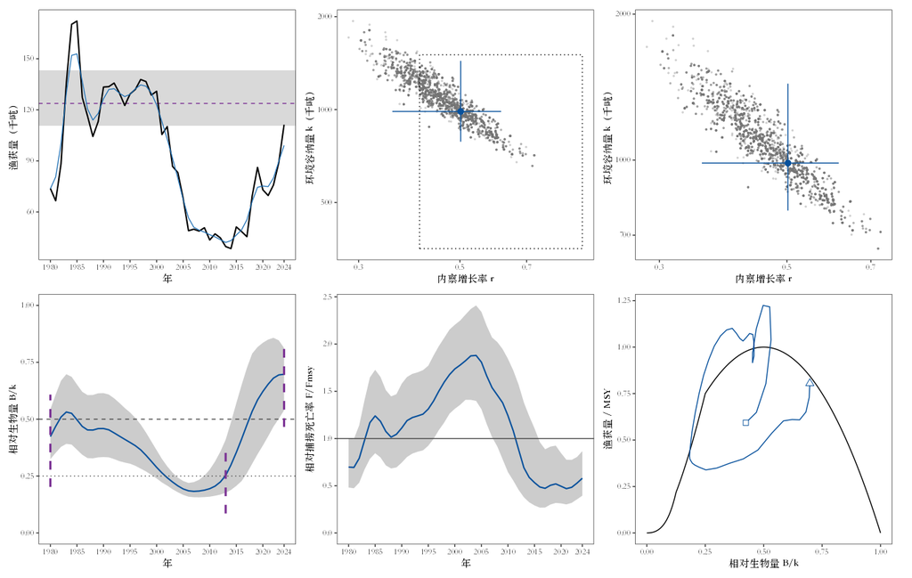

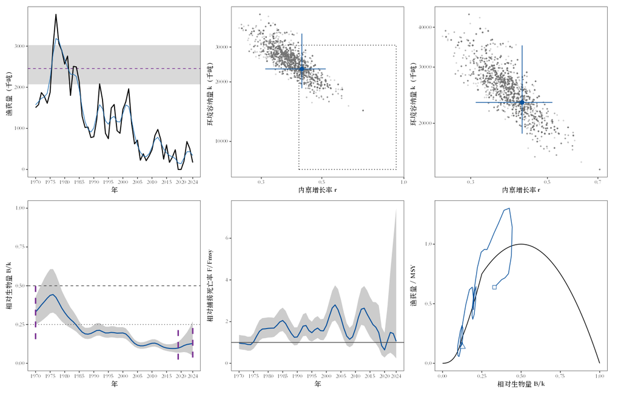

管理图：

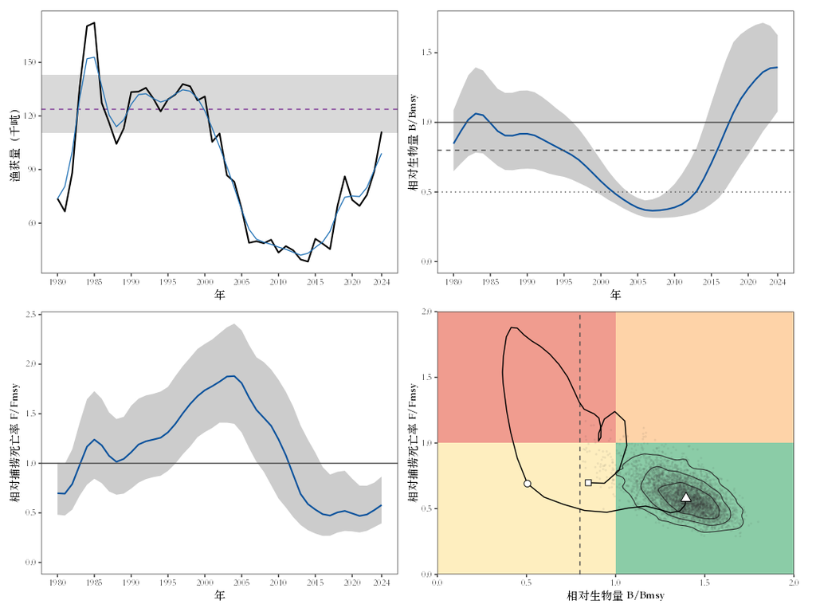

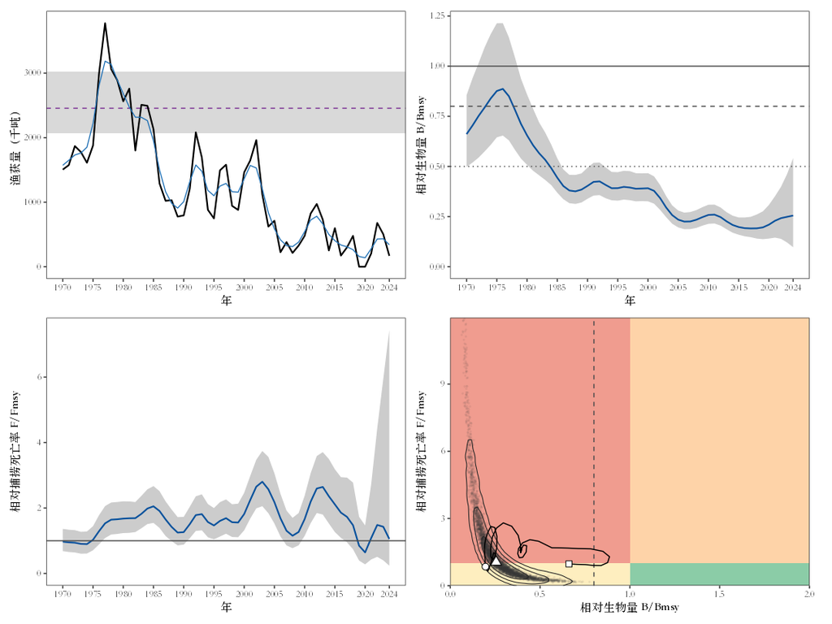

Kobe图（`annotations = TRUE`，打开了全部注释）：

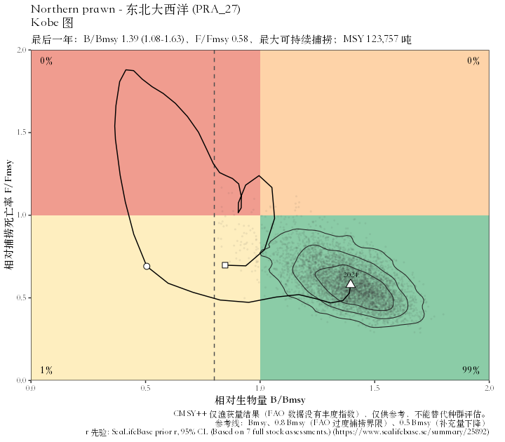

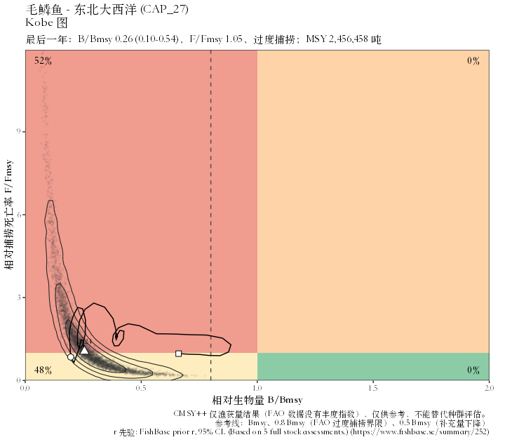

先验与后验分布。PPVR越小，说明数据给先验带来的信息越多：

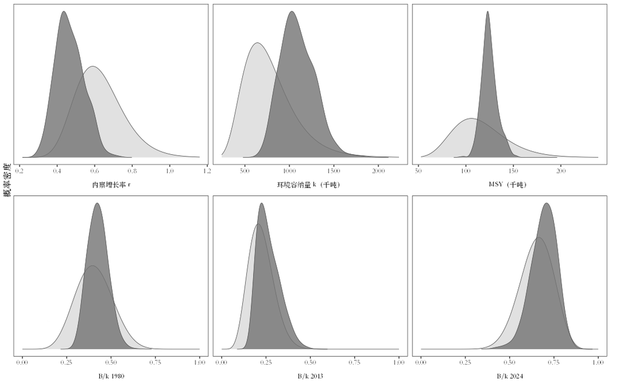

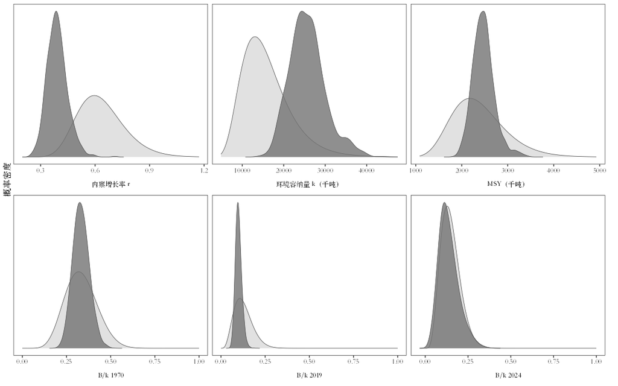

回顾性分析：

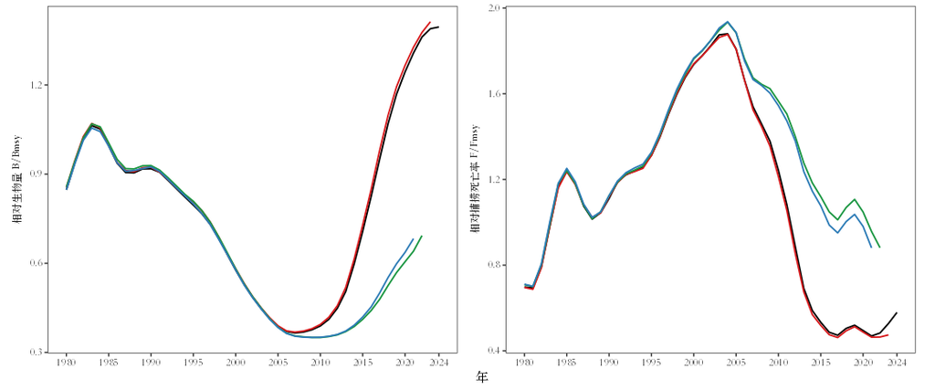

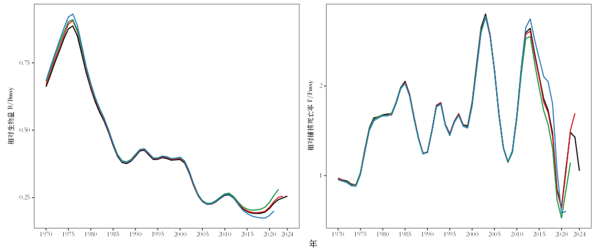

27区前30个种群的汇总图（`annotations = "legend"`）：

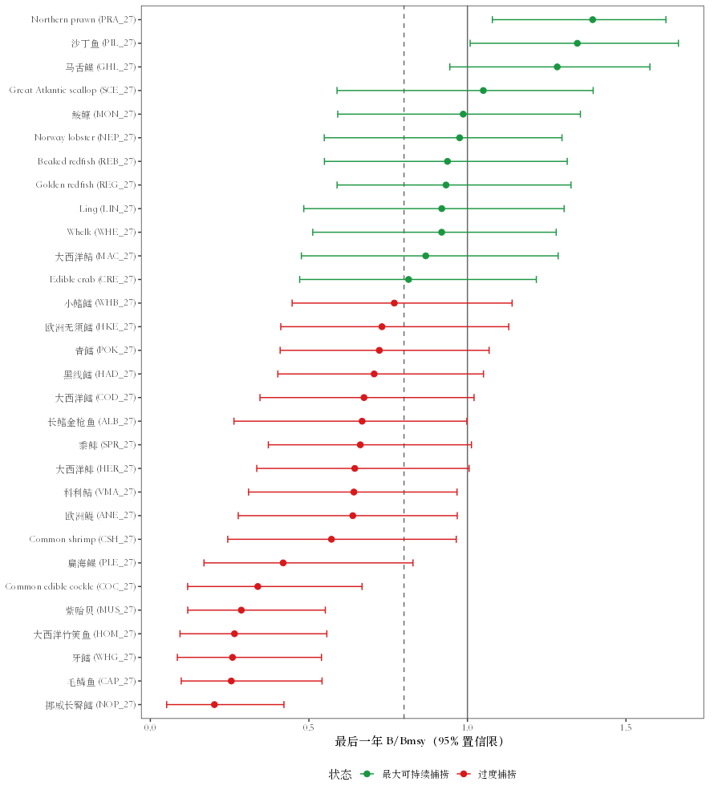

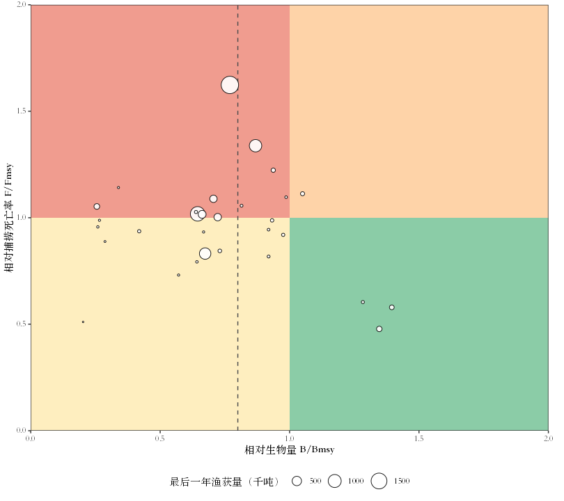

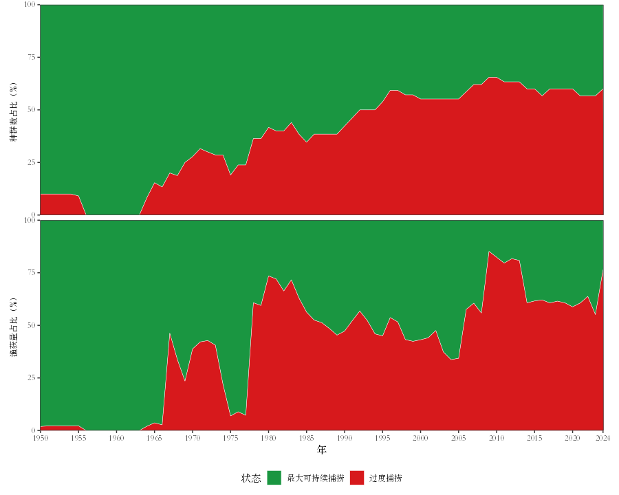

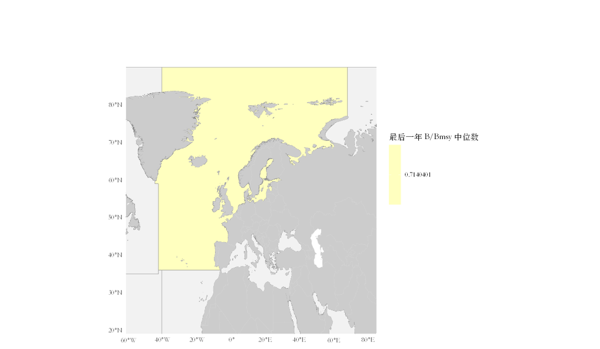

## 🔁 MCMC：设置与收敛诊断

```r
mcmc <- cmsy_mcmc(result)
mcmc$settings        # 每个种群的链数、迭代次数、预烧、抽稀和保留的抽样数
mcmc$diagnostics     # 每个参数的后验统计量、Rhat和有效样本量
cmsy_mcmc(result, colors = c("grey30", "#D7191C"))   # 更换各条链的颜色
```

CMSY++用JAGS以马尔可夫链蒙特卡罗（MCMC）方法从后验分布中抽样。`cmsy_run()`保存r、k、B/k、B/Bmsy和F/Fmsy每条链的抽样（MSY按`CMSY++16.R`的算法由r和k计算），`cmsy_mcmc()`据此做诊断。**Rhat**（Gelman和Rubin，1992）比较链间方差和链内方差，不超过1.1时视为收敛（Gelman等，2013）。**有效样本量**（`n_eff`，用coda计算；Plummer等，2006）是自相关的抽样相当于多少个独立抽样，低于400（Vehtari等，2021）时，95%区间不够精确。未收敛的种群和有效样本量不足的种群分开报告。图中按保留顺序画出每条链的抽样（轨迹：混合良好的链互相重叠、没有趋势）及其密度（各链应当一致）。

下表是两个示例种群分别按`CMSY++16.R`的设置（2条链，每条迭代60,000次，前30,000次作为预烧舍弃，之后每10次保留1次）和用4条链、每条迭代300,000次（预烧150,000次，每50次保留1次；`_long`各列）运行的结果：

```r
mc <- rbind(cbind(stock = "PRA_27", read.csv(file.path(fig_dir, "green_mcmc.csv"), check.names = FALSE)),
            cbind(stock = "CAP_27", read.csv(file.path(fig_dir, "overfished_mcmc.csv"), check.names = FALSE)))
mc <- mc[mc$parameter != "deviance", ]
rk <- mc[mc$parameter %in% c("r", "k", "msy"), ]
shown <- mc[, c("stock", "label", "median", "rhat", "n_eff", "median_long", "rhat_long", "n_eff_long")]
shown[c("median", "median_long")] <- lapply(shown[c("median", "median_long")], function(x)
  vapply(signif(x, 3), format, character(1), big.mark = ",", scientific = FALSE))
shown[c("rhat", "rhat_long")] <- lapply(shown[c("rhat", "rhat_long")], sprintf, fmt = "%.3f")
shown[c("n_eff", "n_eff_long")] <- lapply(shown[c("n_eff", "n_eff_long")], function(x) format(round(x), big.mark = ","))
show_table(data.frame(shown, row.names = NULL), n = 20, digits = 3)
```

| stock | label | median | rhat | n_eff | median_long | rhat_long | n_eff_long |
| --- | --- | --- | --- | --- | --- | --- | --- |
| PRA_27 | 内禀增长率 r | 0.459 | 1.003 | 183 | 0.468 | 1.001 | 1,471 |
| PRA_27 | 环境容纳量 k（吨） | 1,070,000 | 1.002 | 164 | 1,050,000 | 1.001 | 1,254 |
| PRA_27 | MSY（吨） | 124,000 | 1.000 | 151 | 123,000 | 1.001 | 1,451 |
| PRA_27 | 第一年的 B/k | 0.424 | 1.003 | 262 | 0.432 | 1.000 | 1,929 |
| PRA_27 | 最后一年的 B/k | 0.697 | 1.008 | 230 | 0.693 | 1.000 | 1,528 |
| PRA_27 | 最后一年的 B/Bmsy | 1.39 | 1.008 | 230 | 1.39 | 1.000 | 1,528 |
| PRA_27 | 最后一年的 F/Fmsy | 0.579 | 1.001 | 492 | 0.588 | 1.000 | 2,811 |
| CAP_27 | 内禀增长率 r | 0.386 | 1.055 | 256 | 0.383 | 1.001 | 2,105 |
| CAP_27 | 环境容纳量 k（吨） | 25,400,000 | 1.094 | 124 | 25,800,000 | 1.001 | 703 |
| CAP_27 | MSY（吨） | 2,460,000 | 1.034 | 80 | 2,480,000 | 1.000 | 524 |
| CAP_27 | 第一年的 B/k | 0.331 | 1.034 | 216 | 0.326 | 1.000 | 867 |
| CAP_27 | 最后一年的 B/k | 0.128 | 1.018 | 142 | 0.13 | 1.007 | 1,437 |
| CAP_27 | 最后一年的 B/Bmsy | 0.255 | 1.018 | 142 | 0.259 | 1.007 | 1,437 |
| CAP_27 | 最后一年的 F/Fmsy | 1.05 | 1.082 | 262 | 1.03 | 1.022 | 1,926 |

按默认设置，各条链已经收敛（Rhat最大为1.09），但r、k和MSY的有效样本量只有80至256：r和k的相邻抽样高度相关。用更长的链时，有效样本量升至524至2105，而中位数几乎不变（Northern prawn最后一年的B/Bmsy分别为1.395和1.386，毛鳞鱼分别为0.255和0.259）；运行时间约为原来的五倍（4条链与2条链一样同时运行，但每条链长五倍）。要写进报告的结果，建议用更长、更多的链运行CMSY++，并检查收敛情况：

```r
result <- cmsy_run(input, seed = 1, auto_start = TRUE,
                   settings = list(n.chains = 4, n.iter = 300000, n.burnin = 150000, n.thin = 50))
cmsy_mcmc(result)
```

两个示例种群（默认设置）各条链的轨迹和密度，先是Northern prawn，后是毛鳞鱼：

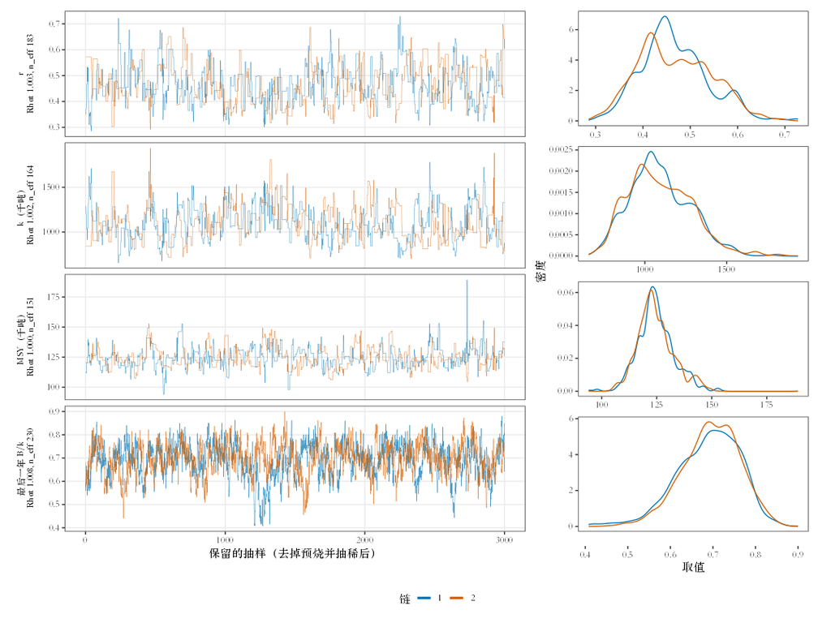

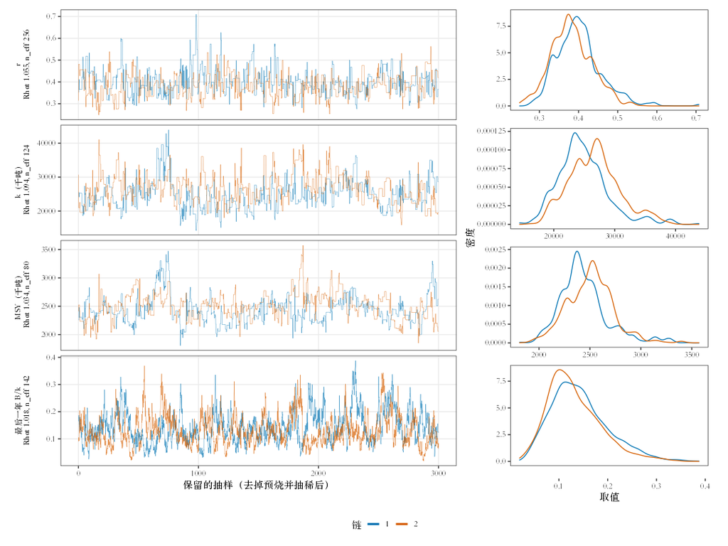

| 参数 | 含义 | 默认值 |
| --- | --- | --- |
| `result` | `cmsy_run()`或`cmsy_area()`的结果 | 必填 |
| `stocks` | 要检查的种群（见通用参数） | `NULL`：所有运行过的种群 |
| `rhat_max` | 视为收敛的最大Rhat | `1.1` |
| `n_eff_min` | 视为足够的最小有效样本量（所有链合计） | `400` |
| `plot`、`table` | 保存图figures/png/cmsy/<种群>/mcmc.png，以及表tables/cmsy/mcmc_settings.csv和mcmc_diagnostics.csv | `TRUE` |
| `colors` | 各条链的颜色：`NULL`（Okabe-Ito配色）、调色板名称（如`"npg"`、`"Set1"`、`"viridis"`）或每条链一个颜色 | `NULL` |
| `lang`、`pptx`、`silent` | 见通用参数 |  |

这张图也是`cmsy_plot()`的`"mcmc"`图（颜色用`mcmc_colors`设置）。本包早期版本的运行结果没有保存抽样，需要重新运行CMSY++才能检查。链收敛并不说明先验或模型适合该种群。

## 🔮 第七步：捕捞情景预测

```r
projection <- cmsy_forecast(result, catch = 100000)
```

`CMSY++16.R`本身没有预测功能。`cmsy_forecast()`用CMSY++自身的模型做预测：Schaefer剩余产量模型，生物量低于0.25 k时生产力线性下降。预测从同一组MCMC迭代的r、k和末年B/k后验抽样出发，加入标准差为`sigma`的对数正态过程误差（默认0.1，即`CMSY++16.R`给设置`sigmaR`的值；模型本身并不使用`sigmaR`，而是估计其过程误差）。与CMSY++相同，某一年的生物量是该年渔获之前的生物量，F是渔获量除以该生物量，F/Fmsy中的Fmsy在生物量低于Bmsy的一半时线性降低。数据最后一年保留其实际渔获量；从第一个预测年起，F情景的渔获量等于情景F乘以同一年的生物量，因此F/Fmsy就是情景值。默认情景是0.5、0.6、0.8、0.95倍Fmsy（与Froese et al. 2018相同），以及维持末年捕捞死亡率；也可以设定固定渔获量（`catch`）。数据结束年份不同的种群，各自从自己的最后一年预测到同一个结束年份。

| 参数 | 含义 | 默认值 |
| --- | --- | --- |
| `result` | `cmsy_run()`的结果 | 必填 |
| `stocks` | 要预测的种群（见通用参数） | `NULL`：已运行的全部种群 |
| `years` | 在各种群最晚的最后一年之后预测的年数 | `10` |
| `f` | 捕捞死亡率情景，Fmsy的倍数 | `c(0.5, 0.6, 0.8, 0.95)` |
| `status_quo` | 是否同时预测维持末年捕捞死亡率的情景 | `TRUE` |
| `catch` | 固定渔获量情景（吨/年） | `NULL` |
| `sigma` | 对数正态过程误差的标准差 | `0.1` |
| `seed` | 随机数种子 | `NULL` |
| `plot` | 是否保存图`figures/png/cmsy/<种群>/forecast.png`和`figures/png/cmsy/summary/forecast_share.png` | `TRUE` |
| `table` | 是否保存`tables/cmsy/forecast.csv`和`forecast_share.csv` | `TRUE` |
| `lang`、`annotations`、`pptx`、`silent` | 见通用参数 |  |

函数返回`projection`（各种群、情景和年份的B/Bmsy、F/Fmsy和渔获量中位数及95%区间，以及B ≥ Bmsy的概率）和`share`（各情景逐年达到或高于Bmsy的种群比例及95%区间，以及种群数`n_stocks`；从各种群最晚的最后一年开始）。

固定渔获量取接近各种群MSY的值（Northern prawn 100,000吨，毛鳞鱼2,000,000吨），另加各F情景：

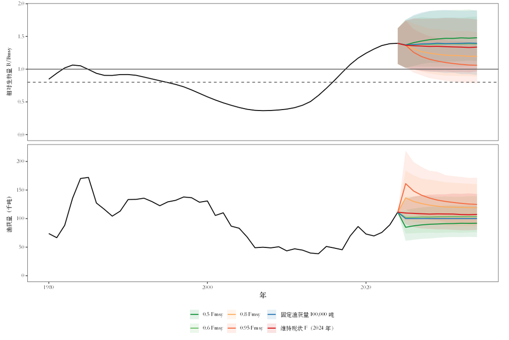

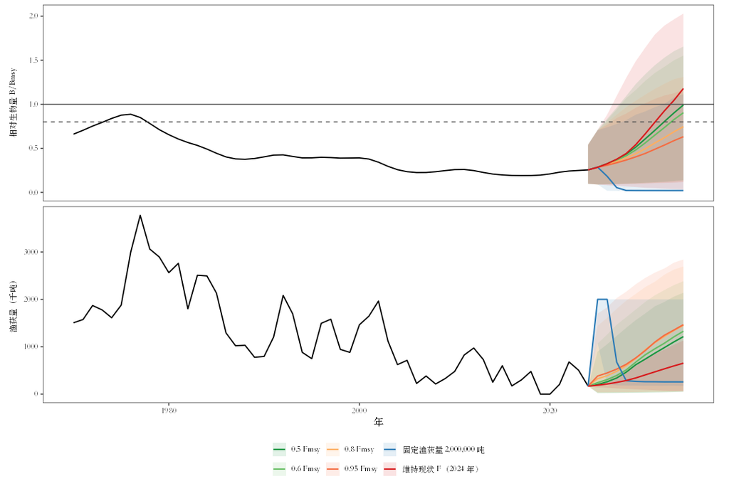

## 🔍 第八步：比较不同运行或其他评估

```r
result_1950 <- cmsy_run(input, stocks = "PRA_27", seed = 1)        # 从1950年开始
cmsy_compare(`1950` = result_1950, `CMSY++` = result, stocks = "PRA_27")
```

`cmsy_compare()`把几次运行（例如不同的起始年或先验，即敏感性分析）以及其他评估的结果（`external`，如ICES、JABBA或文献中的B/Bmsy）画在同一张图上，并给出各自最后一年的值。起始年的影响很大：Northern prawn从1950年开始运行时，最后一年B/Bmsy为0.82，低于Bmsy；按CMSY++建议从1980年开始时为1.39，高于Bmsy。毛鳞鱼无论从哪一年开始都处于过度捕捞状态（从1950年开始为0.25，从1970年开始为0.26）：

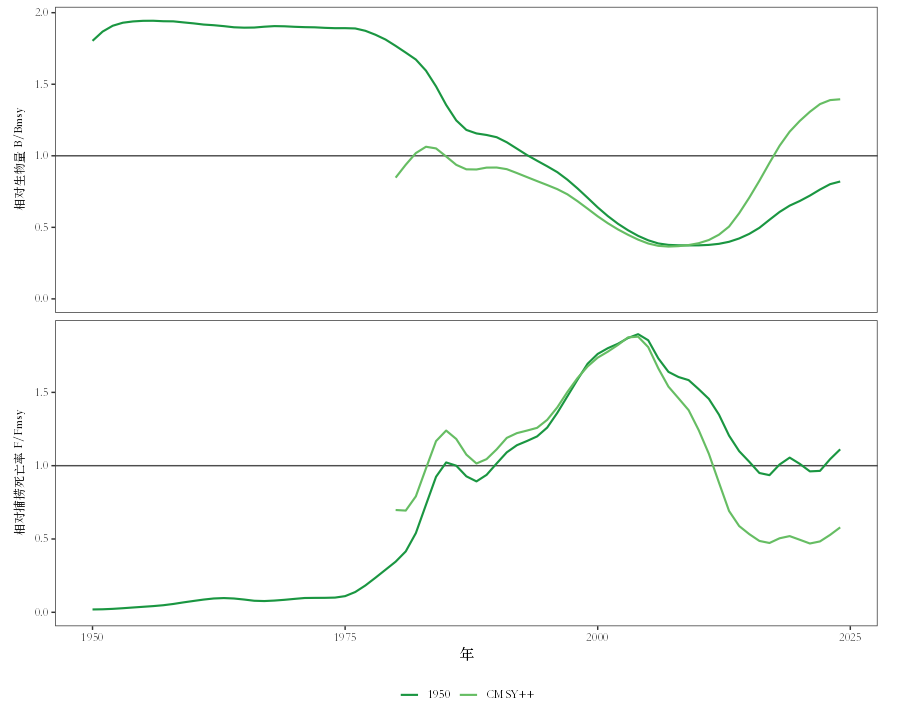

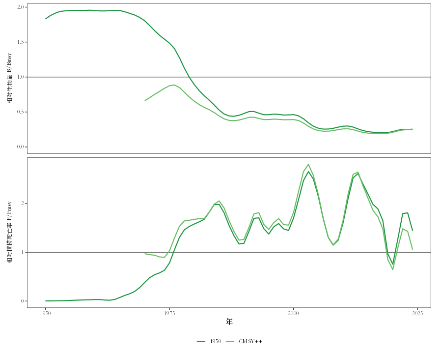

| 参数 | 含义 | 默认值 |
| --- | --- | --- |
| `...` | `cmsy_run()`的结果，可以命名，也可以不命名（如`default = run1, start_1980 = run2`） |  |
| `stocks` | 要画的种群（见通用参数） | `NULL`：已运行的全部种群 |
| `external` | 其他评估结果的数据框，包括`Stock`、`Year`、`B_Bmsy`（可另加`F_Fmsy`）和`source`（图例中显示的名称）列 | `NULL` |
| `lang`、`annotations`、`pptx`、`silent` | 见通用参数 |  |

图保存为`figures/png/cmsy/compare/<种群>.png`；函数返回`last_year`（每个种群每次运行一行）和`plots`。

## 📋 第九步：报告用的表格

```r
tables <- cmsy_tables(result)
```

`cmsy_tables()`生成CMSY文献中常见的两张表，即上文第五步中的先验表和结果表。数值已取整，范围写成“下限-上限”，列名使用所选语言，保存为`tables/cmsy/cmsy_priors_table.csv`和`cmsy_results_table.csv`。结果表同时给出FAO（2026）两级和Palomares et al. (2018)五级的状态。

| 参数 | 含义 | 默认值 |
| --- | --- | --- |
| `result` | `cmsy_run()`的结果 | 必填 |
| `stocks` | 表中的种群（见通用参数） | `NULL`：已运行的全部种群 |
| `table`、`lang`、`silent` | 见通用参数 |  |

## ⚙️ CMSY++自带的设置

CMSY++代码里有一组“一般设置”，例如渔获量观测误差`CV.C`、MCMC链数和迭代次数。其中`sigmaR`和`ni`两项在`CMSY++16.R`中有赋值，但代码并不使用（模型的过程误差由先验`itau2 ~ dgamma(4, 0.01)`估计）：它们标为“not used”（不使用），不能修改，以免误以为做了过程误差的敏感性分析。`cmsy_run()`默认完全沿用CMSY++原来的数值，`cmsy_defaults()`列出每一项的原默认值、实际使用的值和含义：

```r
show_table(cmsy_defaults()[, c("setting", "cmsy_default", "applies_to", "description")], n = 30)
```

| setting | cmsy_default | applies_to | description |
| --- | --- | --- | --- |
| CV.C | 0.15 | all | 渔获量观测误差的变异系数 |
| CV.cpue | 0.2 | BSM | CPUE 的最小变异系数 |
| sigmaR | 0.1 | not used | CMSY++16.R不使用：代码中有赋值（sigR <- sigmaR），但从未使用；模型的过程误差由先验 itau2 ~ dgamma(4, 0.01) 估计。不能修改 |
| cor.log.rk | -0.76 | charts | log r 与 log k 的相关系数，仅用于作图 |
| rk.cor.beta | 2.52, 3.37 | all | r-k 相关系数加 1 的 beta 先验 |
| nbk | 3 | BSM | BSM 使用的 B/k 先验个数：1（首年）、2（加中间年）、3（再加末年） |
| bt4pr | FALSE | BSM | 用丰度数据设定 B/k 先验 |
| ct_MSY.lim | 1.21 | all | 渔获量与 MSY 先验之比超过此值时，B/k 先验保持不变 |
| q.biomass.pr | 0.9, 1.1 | BSM | 丰度数据为生物量时 q 的先验范围 |
| n | 5000 | charts | 分析图中 r-k 点云的点数 |
| ni | 3 | not used | CMSY++16.R不使用：代码中有赋值，但从未使用。不能修改 |
| nab | 3 | BSM | 运行 BSM 所需丰度数据的最少年数 |
| bw | 3 | all | 渔获量平滑（ksmooth()）的带宽 |
| e.creep.line | TRUE | charts | 在生物量图中显示未按渔效增长（effort creep）校正的 CPUE |
| select.yr | NA | output | 另外报告该年 B、F、B/Bmsy 和 F/Fmsy 的年份（NA 为不报告） |
| n.chains | 2 | all | MCMC 链数（JAGS） |
| n.iter | 60000 | all | 每条链的 MCMC 迭代次数（JAGS） |
| n.burnin | 30000 | all | 预烧（burn-in）迭代次数（JAGS） |
| n.thin | 10 | all | MCMC 抽稀间隔（JAGS） |

`applies_to`为”BSM”的设置只在有丰度数据（CPUE或生物量）时才起作用。FAO数据只有渔获量，所以真正影响结果的是标为”all”的设置。需要改时，用`settings`只写要改的几项，其余保持原值；每一项都会先检查（名称、取值范围、迭代次数是否足够）：

```r
cmsy_defaults(list(CV.C = 0.2, n.iter = 100000, n.burnin = 50000))[c(1, 17, 18), c("setting", "cmsy_default", "used", "changed")]
```

```
#>     setting cmsy_default   used changed
#> 1      CV.C         0.15    0.2    TRUE
#> 17   n.iter        60000 100000    TRUE
#> 18 n.burnin        30000  50000    TRUE
```

```r
result <- cmsy_run(input, stocks = "PRA_27", seed = 1, auto_start = TRUE,
                   settings = list(CV.C = 0.2, n.iter = 100000, n.burnin = 50000))
result$settings[result$settings$changed, ]          # 改动的设置
```

| 参数 | 含义 | 默认值 |
| --- | --- | --- |
| `settings` | 要修改的设置，命名列表，如`list(CV.C = 0.2)`；与默认值并列显示并检查 | `list()` |
| `lang` | `description`列的语言：`"en"`、`"zh"`或`"both"` | `NULL`：使用`fao_settings()`设定的语言 |

实际使用的设置保存在运行目录的`settings_used.csv`，也记录在`result$settings`和`result$sources`中。绘图和输出开关（`mgraphs`、`kobe.plot`、`retros`等）由`cmsy_run()`的`plots`参数控制，不在`settings`里设置。

## 🖥️ Windows、macOS和Linux

同一段代码在三个系统上都能直接运行。`cmsy_system()`自动识别系统，并做相应修改，例如macOS上不调用`windows()`、不使用`antialias = "cleartype"`，修改清单见第一步。JAGS安装程序会按系统和R版本自动选择。每次修改CMSY代码，GitHub Actions上的”CMSY-cross-platform”检验都会在三个系统上用`cmsy_download_jags()`下载并安装匹配的JAGS、真实运行CMSY++、运行全部CMSY测试，并保存各系统的输出，方便核对。

2026年10月的检验结果，用的是当时本文示例渔区34区的两个种群（每种组合170项测试全部通过；种子相同，`cmsy_area()`运行大眼裸颌鲈GRB_34和沙丁鱼PIL_34）：

| 系统 | R | JAGS | rjags | GRB_34 B/Bmsy | GRB_34 F/Fmsy | PIL_34 B/Bmsy | PIL_34 F/Fmsy |
| --- | --- | --- | --- | --- | --- | --- | --- |
| Windows | 4.6.1 | 4.3.2 | 4-17 | 1.422 | 0.639 | 0.706 | 1.391 |
| Windows | 4.4.3 | 4.3.1 | 4-17 | 1.422 | 0.639 | 0.706 | 1.391 |
| Windows | 4.3.3 | 4.3.1 | 4-17 | 1.422 | 0.639 | 0.706 | 1.391 |
| Windows | 4.2.3 | 4.3.1 | 4-17 | 1.422 | 0.639 | 0.706 | 1.391 |
| macOS（Apple芯片） | 4.6.1 | 4.3.2 | 4-17 | 1.422 | 0.639 | 0.706 | 1.391 |
| Ubuntu | 4.6.1 | 4.3.2（apt） | 4-17 | 1.422 | 0.639 | 0.706 | 1.391 |
| macOS（Apple芯片） | 4.2.3 | 4.3.1 | 4-15 | 1.366 | 0.663 | 0.745 | 1.306 |
| Windows | 4.6.1 | 5.0.0 | 5-3 | 1.392 | 0.672 | 0.740 | 1.317 |
| macOS（Apple芯片） | 4.6.1 | 5.0.0 | 5-3 | 1.392 | 0.672 | 0.740 | 1.317 |

JAGS 4.3.x和rjags 4-17相同时，三个系统的结果逐位相同。换成JAGS 5或较旧的rjags后，MCMC抽样不同，数值略有差别（GRB_34的B/Bmsy在1.37–1.42之间，都在95%置信区间1.08–1.65内），但两个种群的状态判定都不变：GRB_34为最大可持续捕捞，PIL_34为过度捕捞。要完全重现某次结果，需要使用相同版本的JAGS和rjags；所用版本记录在`result$sources`和`tables/sources.csv`中。

## ⏱️ 进度条与silent

`cmsy_run()`、`cmsy_plot()`、`cmsy_forecast()`和`cmsy_area()`运行时会显示进度条，例如：

```
CMSY++ [==================            ] 18/30 ( 60%) 00:51 elapsed, 00:34 left COD_27
```

所有会输出信息的CMSY函数都有`silent`参数：`silent = TRUE`时不显示进度条和提示信息（`cmsy_setup()`需要确认时仍会询问）。`fao_settings(silent = TRUE)`可以设定本次会话的默认值。

## 📝 写入Word报告

`cmsy = TRUE`时，`fao_report()`会用CMSY++评估该渔区的主要物种（见📝 一键生成评估报告（Word、LaTeX、PDF）），并在报告中加入资源评估部分，给出每个物种的结果，以及参考点、先验及其来源的附表。它对报告的`top_n`个主要物种（默认10个）运行`cmsy_area()`，不做情景预测。`cmsy_area()`和`cmsy_input()`的设置以`cmsy_`为前缀传入，例如`cmsy_top = 5`、`cmsy_default_resilience = "Medium"`或`cmsy_settings = list(n.iter = 100000)`。CMSY++的全部结果（运行、图表和表格）保存在报告旁边的`cmsy/`文件夹中，其中的`cmsy_result.rds`可以用来重写报告而不必重新运行CMSY++：`cmsy = readRDS("cmsy/<渔区>/cmsy_result.rds")`，路径从工作目录算起（默认是`reports/cmsy/<渔区>/cmsy_result.rds`）。以前用`cmsy_area()`得到的结果也可以这样传入。

```r
report <- fao_report(27, cmsy = TRUE, cmsy_top = 5)
report$cmsy_reference_points                  # r、k、MSY、B/Bmsy等及其95%置信限
fao_report(27, cmsy = readRDS("reports/cmsy/Atlantic__Northeast/cmsy_result.rds"))
```

## 📖 参考文献

Boettiger, C., Lang, D.T. and Wainwright, P.C. (2012). rfishbase: exploring, manipulating and visualizing FishBase data from R. *Journal of Fish Biology* 81(6): 2030–2039. [doi:10.1111/j.1095-8649.2012.03464.x](https://doi.org/10.1111/j.1095-8649.2012.03464.x). Source code: https://github.com/ropensci/rfishbase

FAO (2026). *Global Capture Production 1950–2024*, release 2026.1.0. In: Fisheries and Aquaculture. Rome: FAO. https://www.fao.org/fishery/collection/capture/en. Licence: CC BY 4.0. Release file: https://www.fao.org/fishery/static/Data/Capture_2026.1.0.zip

FAO (2026). *The State of World Fisheries and Aquaculture 2026 – Blue Transformation: turning vision into impact*. Rome: FAO. [doi:10.4060/cd8357en](https://doi.org/10.4060/cd8357en). Section “The status of fishery resources”, Box 1.3 (assessment tiers and status classes): https://openknowledge.fao.org/server/api/core/bitstreams/09d03e2f-7097-4d59-bf94-db65e95f44fd/content/sofia-2026/the-status-fishery-resources.html

Free, C.M., Jensen, O.P., Anderson, S.C., Gutierrez, N.L., Kleisner, K.M., Longo, C., Minto, C., Osio, G.C. and Walsh, J.C. (2020). Blood from a stone: performance of catch-only methods in estimating stock biomass status. *Fisheries Research* 223: 105452. [doi:10.1016/j.fishres.2019.105452](https://doi.org/10.1016/j.fishres.2019.105452)

Froese, R., Demirel, N., Coro, G., Kleisner, K.M. and Winker, H. (2017). Estimating fisheries reference points from catch and resilience. *Fish and Fisheries* 18: 506–526. [doi:10.1111/faf.12190](https://doi.org/10.1111/faf.12190)

Froese, R., Demirel, N., Coro, G. and Winker, H. (2021). *User Guide for CMSY++*. GEOMAR, Germany, 17 pp. https://oceanrep.geomar.de/id/eprint/52147/ (bundled with the package: `system.file("cmsy", "CMSYUserGuideMarch2021.pdf", package = "faofishingreport")`)

Froese, R. and Pauly, D. (Eds.) (2026). FishBase. World Wide Web electronic publication. Version (06/2026). https://www.fishbase.se

Froese, R., Winker, H., Coro, G., Demirel, N., Tsikliras, A.C., Dimarchopoulou, D., Scarcella, G., Quaas, M. and Matz-Lück, N. (2018). Status and rebuilding of European fisheries. *Marine Policy* 93: 159–170. [doi:10.1016/j.marpol.2018.04.018](https://doi.org/10.1016/j.marpol.2018.04.018)

Froese, R., Winker, H., Coro, G., Palomares, M.L.D., Tsikliras, A.C., Dimarchopoulou, D., Touloumis, K., Demirel, N., Vianna, G.M.S., Scarcella, G., Schijns, R., Liang, C. and Pauly, D. (2023). New developments in the analysis of catch time series as the basis for fish stock assessments: the CMSY++ method. *Acta Ichthyologica et Piscatoria* 53: 173–189. [doi:10.3897/aiep.53.105910](https://doi.org/10.3897/aiep.53.105910)

Gelman, A., Carlin, J.B., Stern, H.S., Dunson, D.B., Vehtari, A. and Rubin, D.B. (2013). *Bayesian Data Analysis*, 3rd edition. Boca Raton: CRC Press. [doi:10.1201/b16018](https://doi.org/10.1201/b16018)

Gelman, A. and Rubin, D.B. (1992). Inference from iterative simulation using multiple sequences. *Statistical Science* 7(4): 457–472. [doi:10.1214/ss/1177011136](https://doi.org/10.1214/ss/1177011136)

Kell, L.T., Sharma, R. and Winker, H. (2022). Artefact and artifice: evaluation of the skill of catch-only methods for classifying stock status. *Frontiers in Marine Science* 9: 762203. [doi:10.3389/fmars.2022.762203](https://doi.org/10.3389/fmars.2022.762203)

Mohn, R. (1999). The retrospective problem in sequential population analysis: an investigation using cod fishery and simulated data. *ICES Journal of Marine Science* 56: 473–488. [doi:10.1006/jmsc.1999.0481](https://doi.org/10.1006/jmsc.1999.0481)

Ovando, D., Hilborn, R., Monnahan, C., Rudd, M., Sharma, R., Thorson, J.T., Rousseau, Y. and Ye, Y. (2021). Improving estimates of the state of global fisheries depends on better data. *Fish and Fisheries* 22: 1377–1391. [doi:10.1111/faf.12593](https://doi.org/10.1111/faf.12593)

Palomares, M.L.D., Froese, R., Derrick, B., Nöel, S.-L., Tsui, G., Woroniak, J. and Pauly, D. (2018). *A preliminary global assessment of the status of exploited marine fish and invertebrate populations*. A report prepared by the Sea Around Us for OCEANA. University of British Columbia and GEOMAR. https://www.fishbase.de/rfroese/OceanaFinalReport_V7a.pdf

Palomares, M.L.D. and Pauly, D. (Eds.) (2026). SeaLifeBase. World Wide Web electronic publication. Version (06/2026). https://www.sealifebase.se

Plummer, M. (2003). JAGS: a program for analysis of Bayesian graphical models using Gibbs sampling. In: *Proceedings of the 3rd International Workshop on Distributed Statistical Computing (DSC 2003)*, Vienna, 1–10. https://www.r-project.org/conferences/DSC-2003/Proceedings/Plummer.pdf; JAGS: https://mcmc-jags.sourceforge.io/

Plummer, M., Best, N., Cowles, K. and Vines, K. (2006). CODA: convergence diagnosis and output analysis for MCMC. *R News* 6(1): 7–11. https://journal.r-project.org/articles/RN-2006-002/

Plummer, M. (2025). rjags: Bayesian Graphical Models using MCMC. R package version 4-17. [doi:10.32614/CRAN.package.rjags](https://doi.org/10.32614/CRAN.package.rjags)

Su, Y. and Yajima, M. (2024). R2jags: Using R to Run ‘JAGS’. R package version 0.8-9. [doi:10.32614/CRAN.package.R2jags](https://doi.org/10.32614/CRAN.package.R2jags)

Vehtari, A., Gelman, A., Simpson, D., Carpenter, B. and Bürkner, P.-C. (2021). Rank-normalization, folding, and localization: an improved Rhat for assessing convergence of MCMC. *Bayesian Analysis* 16(2): 667–718. [doi:10.1214/20-BA1221](https://doi.org/10.1214/20-BA1221)